# Neural-Network Manhours Model — Crew-Day Batching (v15: v13 + setup/travel check, holdout R² scatter)

```python
class WeightEMA:
    """v12 change: running average of the network's weights; evaluation and saving use the averaged copy."""

    def __init__(self, model, decay):
        self.model = copy.deepcopy(model)
        self.decay, self.steps = decay, 0
        for p in self.model.parameters():
            p.requires_grad_(False)

    @torch.no_grad()
    def update(self, model):
        self.steps += 1
        d = min(self.decay, (1 + self.steps) / (10 + self.steps))   # early on, follow the live model closely
        for e, p in zip(self.model.parameters(), model.parameters()):
            e.mul_(d).add_(p.detach(), alpha=1.0 - d)


def train_model(target_mode, spec, run_name, seed=SEED):
    set_seed(seed)
    fit = DATA["fit"]
    model = CrewDayNet(fit["x_num"].shape[1], PREP.cardinalities, spec["width"], spec["n_blocks"],
                       spec["dropout"], spec["emb_dropout"]).to(DEVICE)
    with torch.no_grad():   # start every span at the fitting-set mean (inverse softplus)
        model.head.bias.fill_(float(np.log(np.expm1(NAIVE_SPAN))))
    ema = WeightEMA(model, EMA_DECAY) if EMA_DECAY else None
    opt = torch.optim.AdamW(model.parameters(), lr=spec["lr"], weight_decay=spec["weight_decay"])
    sched = torch.optim.lr_scheduler.ReduceLROnPlateau(opt, mode="min", factor=0.1,
                                                       patience=9)
    batches = CrewDayBatches(fit["cd"], CREW_DAYS_PER_BATCH, shuffle=True, seed=seed)
    warmup_steps = WARMUP_EPOCHS * len(batches)
    writer = make_writer(run_name)
    if writer:
        writer.add_text("config", f"target_mode={target_mode} | spec={spec} | seed={seed} | "
                                  f"CREW_DAYS_PER_BATCH={CREW_DAYS_PER_BATCH} | L1_INPUT_PENALTY={L1_INPUT_PENALTY} | "
                                  f"EMA_DECAY={EMA_DECAY} | WARMUP_EPOCHS={WARMUP_EPOCHS} | "
                                  f"SPAN_AUX_WEIGHT={SPAN_AUX_WEIGHT} | features={len(feature_cols)}")

    best_smooth, best_state, best_epoch, stale, history, step = float("inf"), None, -1, 0, [], 0
    recent_scores = []
    t0 = time.time()
    for epoch in range(NN_CFG["max_epochs"]):
        model.train()
        loss_sums, grad_norms, n_steps = defaultdict(float), [], 0
        for span_pos, local in batches:
            if step < warmup_steps:   # v12 change: linear warm-up from 10% of the learning rate
                for g in opt.param_groups:
                    g["lr"] = spec["lr"] * (0.1 + 0.9 * (step + 1) / warmup_steps)
            pos = torch.from_numpy(span_pos)
            pred = model(fit["x_num"][pos].to(DEVICE), fit["x_cat"][pos].to(DEVICE))
            loss, parts = batch_loss(pred, fit["y"][pos].to(DEVICE), torch.from_numpy(local).to(DEVICE),
                                     target_mode, spec)
            if L1_INPUT_PENALTY:   # v12 change: L1 on first-layer weights (feature selection instead of RFE)
                l1 = L1_INPUT_PENALTY * model.first_layer.weight.abs().sum()
                loss = loss + l1
                parts["l1"] = l1.item()
            opt.zero_grad(set_to_none=True)
            loss.backward()
            grad_norms.append(float(nn.utils.clip_grad_norm_(model.parameters(), 5.0)))
            opt.step()
            if ema:
                ema.update(model)
            loss_sums["total"] += loss.item()
            for k, v in parts.items():
                loss_sums[k] += v
            n_steps += 1
            step += 1

        eval_model = ema.model if ema else model
        preds = {name: predict(eval_model, DATA[name]) for name in ("fit", "early_stop", "validation")}
        # v12 change: score on predictions rescaled so early-stop totals match (as used after Step 5c)
        s = total_scale(DATA["early_stop"], preds["early_stop"]) if SCORE_ON_SCALED else 1.0
        metrics = {name: score(DATA[name], s * p) for name, p in preds.items()}
        es_score = metrics["early_stop"]["score"]
        recent_scores = (recent_scores + [es_score])[-ES_SMOOTH_EPOCHS:]
        smooth = float(np.mean(recent_scores))   # v12 change: decisions follow the recent average
        in_warmup = step <= warmup_steps
        if not in_warmup:
            sched.step(smooth)
        row = {"epoch": epoch, "lr": opt.param_groups[0]["lr"], "grad_norm": float(np.mean(grad_norms)),
               "scale": s, "score_smoothed": smooth,
               **{f"loss_{k}": v / n_steps for k, v in loss_sums.items()},
               **{f"{split}_{k}": v for split, m in metrics.items() for k, v in m.items()}}
        history.append(row)

        if writer:
            for k, v in loss_sums.items():
                writer.add_scalar(f"loss/{k}", v / n_steps, epoch)
            for split, m in metrics.items():   # validation is logged for monitoring only - never selects epochs
                for k in ("span_mae", "crew_day_mae", "feeder_wape", "device_wape", "bias_per_span",
                          "allocation_skill"):
                    if k in m:
                        writer.add_scalar(f"{k}/{split}", m[k], epoch)
            for k in ("span_ratio", "feeder_ratio", "device_ratio"):   # v12 change: what drives the score
                if k in metrics["early_stop"]:
                    writer.add_scalar(f"score_parts/{k}", metrics["early_stop"][k], epoch)
            writer.add_scalar("score/early_stop", es_score, epoch)
            writer.add_scalar("score/early_stop_smoothed", smooth, epoch)
            writer.add_scalar("score/validation", metrics["validation"]["score"], epoch)
            writer.add_scalar("optim/lr", row["lr"], epoch)
            writer.add_scalar("optim/grad_norm", row["grad_norm"], epoch)
            writer.add_scalar("optim/early_stop_scale", s, epoch)

        if smooth < best_smooth - 1e-4:
            best_smooth, best_epoch, stale = smooth, epoch, 0
            best_state = copy.deepcopy(eval_model.state_dict())
        elif not in_warmup:
            stale += 1
        if epoch % 10 == 0 or stale == 0:
            print(f"[{run_name}] epoch {epoch:>3} | loss {row['loss_total']:.3f} | early-stop span MAE "
                  f"{metrics['early_stop']['span_mae']:.3f}, feeder WAPE {metrics['early_stop']['feeder_wape']:.3f}"
                  f" | score {es_score:.4f} (smoothed {smooth:.4f}){' *' if stale == 0 else ''}")
        if stale >= NN_CFG["patience"]:
            break
```

```python
    model.load_state_dict(best_state)   # best (averaged) weights
    history = pd.DataFrame(history)
    print(f"[{run_name}] best epoch {best_epoch} of {epoch + 1} run | {time.time() - t0:.0f}s")
    if writer:   # HPARAMS tab: one row per seed run, metrics at its best epoch (scaled if SCORE_ON_SCALED)
        best = history.loc[history["epoch"] == best_epoch].iloc[0]
        hparams = {"target_mode": target_mode, "loss": spec["loss"], "seed": seed, "width": spec["width"],
                   "n_blocks": spec["n_blocks"], "dropout": spec["dropout"], "emb_dropout": spec["emb_dropout"],
                   "lr": spec["lr"], "weight_decay": spec["weight_decay"], "crew_days_per_batch": CREW_DAYS_PER_BATCH,
                   "span_aux_weight": SPAN_AUX_WEIGHT, "l1_input_penalty": L1_INPUT_PENALTY,
                   "ema_decay": EMA_DECAY or 0.0, "warmup_epochs": WARMUP_EPOCHS, "n_features": len(feature_cols),
                   "split": SPLIT_USED}
        keys = ("early_stop_score", "validation_score", "validation_span_mae", "validation_feeder_wape",
                "validation_device_wape", "validation_bias_per_span", "validation_allocation_skill")
        writer.add_hparams(hparams, {f"hparam/{k}": float(best[k]) for k in keys
                                     if k in best.index and np.isfinite(best[k])}, run_name=".")
        writer.close()
    return {"model": model, "history": history, "best_epoch": best_epoch}
```

### 5b. Train

```python
SPEC = {k: DEFAULT_SPEC[k] for k in ("loss", "width", "n_blocks", "dropout", "emb_dropout", "lr", "weight_decay")}
RUN_STAMP = time.strftime("%Y%m%d-%H%M%S")
SEEDS = [SEED + i for i in range(1 if FAST else N_SEEDS)]   # v12 change: several seeds per run
if FAST:
    print(f"NOTE: RUN_MODE is FAST - {NN_CFG['max_epochs']} epochs max, patience {NN_CFG['patience']}, one seed. "
          f"Use the full mode for real comparisons.")
print(f"Base spec: {SPEC} | crew-days per batch {CREW_DAYS_PER_BATCH} | L1 {L1_INPUT_PENALTY} | "
      f"EMA {EMA_DECAY} | warm-up {WARMUP_EPOCHS} epochs | seeds {SEEDS} | {len(feature_cols)} features")

RESULTS = {}
for run in TRAINING_RUNS:
    name = f"{run['mode']}_{run['loss']}"
    spec = {**SPEC, "loss": run["loss"]}
    fits = [train_model(run["mode"], spec, run_name=f"{RUN_STAMP}_{name}_s{sd}", seed=sd) for sd in SEEDS]
    RESULTS[name] = {"mode": run["mode"], "loss": run["loss"], "spec": spec, "seeds": SEEDS,
                     "models": [f["model"] for f in fits], "histories": [f["history"] for f in fits],
                     "best_epochs": [f["best_epoch"] for f in fits]}
```

```
Base spec: {'loss': 'l1', 'width': 128, 'n_blocks': 2, 'dropout': 0.3, 'emb_dropout': 0.1, 'lr': 0.0003, 'weight_decay': 0.001} | crew-days per batch 128 | L1 0.0001 | EMA 0.98 | warm-up 5 epochs | seeds [42, 43, 44] | 134 features
[20261014-035746_crew_day_l1_s42] epoch   0 | loss 10.715 | early-stop span MAE 1.266, feeder WAPE 0.204 | score 0.3446 (smoothed 0.3446) *
[20261014-035746_crew_day_l1_s42] epoch   1 | loss 10.429 | early-stop span MAE 1.252, feeder WAPE 0.203 | score 0.3413 (smoothed 0.3430) *
[20261014-035746_crew_day_l1_s42] epoch   2 | loss 9.908 | early-stop span MAE 1.232, feeder WAPE 0.201 | score 0.3366 (smoothed 0.3409) *
[20261014-035746_crew_day_l1_s42] epoch   3 | loss 9.204 | early-stop span MAE 1.206, feeder WAPE 0.198 | score 0.3305 (smoothed 0.3362) *
[20261014-035746_crew_day_l1_s42] epoch   4 | loss 9.885 | early-stop span MAE 1.175, feeder WAPE 0.197 | score 0.3242 (smoothed 0.3304) *
[20261014-035746_crew_day_l1_s42] epoch   5 | loss 9.253 | early-stop span MAE 1.139, feeder WAPE 0.195 | score 0.3163 (smoothed 0.3236) *
[20261014-035746_crew_day_l1_s42] epoch   6 | loss 8.132 | early-stop span MAE 1.105, feeder WAPE 0.191 | score 0.3076 (smoothed 0.3160) *
[20261014-035746_crew_day_l1_s42] epoch   7 | loss 8.297 | early-stop span MAE 1.075, feeder WAPE 0.186 | score 0.2999 (smoothed 0.3079) *
[20261014-035746_crew_day_l1_s42] epoch   8 | loss 8.027 | early-stop span MAE 1.050, feeder WAPE 0.180 | score 0.2921 (smoothed 0.2999) *
[20261014-035746_crew_day_l1_s42] epoch   9 | loss 8.048 | early-stop span MAE 1.031, feeder WAPE 0.174 | score 0.2852 (smoothed 0.2924) *
[20261014-035746_crew_day_l1_s42] epoch  10 | loss 7.135 | early-stop span MAE 1.017, feeder WAPE 0.166 | score 0.2780 (smoothed 0.2851) *
[20261014-035746_crew_day_l1_s42] epoch  11 | loss 7.079 | early-stop span MAE 1.006, feeder WAPE 0.156 | score 0.2705 (smoothed 0.2779) *
[20261014-035746_crew_day_l1_s42] epoch  12 | loss 7.162 | early-stop span MAE 0.997, feeder WAPE 0.145 | score 0.2625 (smoothed 0.2703) *
[20261014-035746_crew_day_l1_s42] epoch  13 | loss 7.238 | early-stop span MAE 0.990, feeder WAPE 0.135 | score 0.2556 (smoothed 0.2629) *
[20261014-035746_crew_day_l1_s42] epoch  14 | loss 8.066 | early-stop span MAE 0.992, feeder WAPE 0.132 | score 0.2542 (smoothed 0.2574) *
[20261014-035746_crew_day_l1_s42] epoch  15 | loss 6.614 | early-stop span MAE 1.000, feeder WAPE 0.131 | score 0.2554 (smoothed 0.2551) *
[20261014-035746_crew_day_l1_s42] epoch  20 | loss 6.194 | early-stop span MAE 1.063, feeder WAPE 0.134 | score 0.2684 (smoothed 0.2653)
[20261014-035746_crew_day_l1_s42] epoch  30 | loss 6.632 | early-stop span MAE 1.105, feeder WAPE 0.138 | score 0.2785 (smoothed 0.2781)
[20261014-035746_crew_day_l1_s42] epoch  40 | loss 6.416 | early-stop span MAE 1.111, feeder WAPE 0.140 | score 0.2805 (smoothed 0.2804)
[20261014-035746_crew_day_l1_s42] best epoch 15 of 41 run | 11s
[20261014-035746_crew_day_l1_s43] epoch   0 | loss 11.112 | early-stop span MAE 1.253, feeder WAPE 0.205 | score 0.3426 (smoothed 0.3426) *
[20261014-035746_crew_day_l1_s43] epoch   1 | loss 9.776 | early-stop span MAE 1.238, feeder WAPE 0.204 | score 0.3396 (smoothed 0.3411) *
[20261014-035746_crew_day_l1_s43] epoch   2 | loss 9.587 | early-stop span MAE 1.216, feeder WAPE 0.203 | score 0.3348 (smoothed 0.3390) *
[20261014-035746_crew_day_l1_s43] epoch   3 | loss 9.971 | early-stop span MAE 1.190, feeder WAPE 0.202 | score 0.3295 (smoothed 0.3346) *
[20261014-035746_crew_day_l1_s43] epoch   4 | loss 8.639 | early-stop span MAE 1.157, feeder WAPE 0.201 | score 0.3227 (smoothed 0.3290) *
[20261014-035746_crew_day_l1_s43] epoch   5 | loss 9.557 | early-stop span MAE 1.123, feeder WAPE 0.200 | score 0.3161 (smoothed 0.3228) *
[20261014-035746_crew_day_l1_s43] epoch   6 | loss 7.977 | early-stop span MAE 1.098, feeder WAPE 0.196 | score 0.3097 (smoothed 0.3162) *
[20261014-035746_crew_day_l1_s43] epoch   7 | loss 8.367 | early-stop span MAE 1.080, feeder WAPE 0.191 | score 0.3033 (smoothed 0.3097) *
[20261014-035746_crew_day_l1_s43] epoch   8 | loss 7.316 | early-stop span MAE 1.067, feeder WAPE 0.183 | score 0.2968 (smoothed 0.3033) *
[20261014-035746_crew_day_l1_s43] epoch   9 | loss 7.510 | early-stop span MAE 1.055, feeder WAPE 0.175 | score 0.2897 (smoothed 0.2966) *
[20261014-035746_crew_day_l1_s43] epoch  10 | loss 7.545 | early-stop span MAE 1.040, feeder WAPE 0.165 | score 0.2813 (smoothed 0.2893) *
[20261014-035746_crew_day_l1_s43] epoch  11 | loss 6.988 | early-stop span MAE 1.025, feeder WAPE 0.151 | score 0.2711 (smoothed 0.2807) *
[20261014-035746_crew_day_l1_s43] epoch  12 | loss 6.742 | early-stop span MAE 1.012, feeder WAPE 0.139 | score 0.2622 (smoothed 0.2715) *
[20261014-035746_crew_day_l1_s43] epoch  13 | loss 6.539 | early-stop span MAE 1.009, feeder WAPE 0.137 | score 0.2600 (smoothed 0.2644) *
[20261014-035746_crew_day_l1_s43] epoch  14 | loss 6.703 | early-stop span MAE 1.014, feeder WAPE 0.135 | score 0.2602 (smoothed 0.2608) *
[20261014-035746_crew_day_l1_s43] epoch  15 | loss 6.310 | early-stop span MAE 1.025, feeder WAPE 0.135 | score 0.2619 (smoothed 0.2607) *
[20261014-035746_crew_day_l1_s43] epoch  20 | loss 6.076 | early-stop span MAE 1.103, feeder WAPE 0.145 | score 0.2817 (smoothed 0.2788)
[20261014-035746_crew_day_l1_s43] epoch  30 | loss 6.317 | early-stop span MAE 1.117, feeder WAPE 0.146 | score 0.2851 (smoothed 0.2847)
[20261014-035746_crew_day_l1_s43] epoch  40 | loss 6.338 | early-stop span MAE 1.122, feeder WAPE 0.148 | score 0.2869 (smoothed 0.2868)
```

[output cut: 242 more lines]

```
[20261014-035746_crew_day_poisson_s44] epoch   6 | loss -48.475 | early-stop span MAE 1.099, feeder WAPE 0.186 | score 0.3041 (smoothed 0.3104) *
[20261014-035746_crew_day_poisson_s44] epoch   7 | loss -54.632 | early-stop span MAE 1.087, feeder WAPE 0.182 | score 0.2995 (smoothed 0.3045) *
[20261014-035746_crew_day_poisson_s44] epoch   8 | loss -52.545 | early-stop span MAE 1.078, feeder WAPE 0.176 | score 0.2944 (smoothed 0.2994) *
[20261014-035746_crew_day_poisson_s44] epoch   9 | loss -48.201 | early-stop span MAE 1.070, feeder WAPE 0.168 | score 0.2888 (smoothed 0.2943) *
[20261014-035746_crew_day_poisson_s44] epoch  10 | loss -52.318 | early-stop span MAE 1.065, feeder WAPE 0.160 | score 0.2833 (smoothed 0.2889) *
[20261014-035746_crew_day_poisson_s44] epoch  11 | loss -51.691 | early-stop span MAE 1.061, feeder WAPE 0.151 | score 0.2778 (smoothed 0.2833) *
[20261014-035746_crew_day_poisson_s44] epoch  12 | loss -49.728 | early-stop span MAE 1.058, feeder WAPE 0.142 | score 0.2718 (smoothed 0.2776) *
[20261014-035746_crew_day_poisson_s44] epoch  13 | loss -56.632 | early-stop span MAE 1.057, feeder WAPE 0.131 | score 0.2656 (smoothed 0.2717) *
[20261014-035746_crew_day_poisson_s44] epoch  14 | loss -47.580 | early-stop span MAE 1.057, feeder WAPE 0.124 | score 0.2616 (smoothed 0.2663) *
[20261014-035746_crew_day_poisson_s44] epoch  15 | loss -51.451 | early-stop span MAE 1.058, feeder WAPE 0.122 | score 0.2609 (smoothed 0.2627) *
[20261014-035746_crew_day_poisson_s44] epoch  16 | loss -47.907 | early-stop span MAE 1.061, feeder WAPE 0.122 | score 0.2612 (smoothed 0.2612) *
[20261014-035746_crew_day_poisson_s44] epoch  20 | loss -47.408 | early-stop span MAE 1.094, feeder WAPE 0.127 | score 0.2701 (smoothed 0.2669)
[20261014-035746_crew_day_poisson_s44] epoch  30 | loss -47.297 | early-stop span MAE 1.143, feeder WAPE 0.138 | score 0.2854 (smoothed 0.2850)
[20261014-035746_crew_day_poisson_s44] epoch  40 | loss -50.940 | early-stop span MAE 1.148, feeder WAPE 0.139 | score 0.2865 (smoothed 0.2864)
[20261014-035746_crew_day_poisson_s44] best epoch 16 of 42 run | 10s
```

```python
feature_cols
```

```
['bay_blue_count',
 'bay_blue_volume_(cubic_ft)',
 'bay_green_count',
 'bay_green_volume_(cubic_ft)',
 'bay_l&r_blue_(ft)',
 'bay_l&r_green_(ft)',
 'bay_l&r_orange_(ft)',
 'bay_l&r_purple_ft',
 'bay_l&r_red_(ft)',
 'bay_l&r_yellow_(ft)',
 'bay_length_(ft)',
 'bay_lvl_blue_(ft)',
 'bay_lvl_green_(ft)',
 'bay_lvl_orange_(ft)',
 'bay_lvl_purple_(ft)',
 'bay_lvl_red_(ft)',
 'bay_lvl_yellow_(ft)',
 'bay_minimum_distance_to_ccl',
 'bay_oh_count',
 'bay_oh_volume_(cubic_ft)',
 'bay_orange_count',
 'bay_orange_volume_(cubic_ft)',
 'bay_os_count',
 'bay_os_volume_(cubic_ft)',
 'bay_purple_count',
 'bay_purple_volume_(cubic_ft)',
 'bay_red_count',
 'bay_red_volume_(cubic_ft)',
 'bay_total_intrusion_count',
 'bay_total_intrusion_volume_(cubic_ft)',
 'bay_total_span_length_(ft)',
 'bay_ug_count',
 'bay_ug_volume_(cubic_ft)',
 'bay_worktype_n',
 'bay_yellow_count',
 'bay_yellow_volume_(cubic_ft)',
 'heavy_contact_cond',
 'heavy_contact_count',
 'heavy_contact_flag',
 'heavy_contact_ratio',
```

[output cut: 79 more lines]

```
 'alley_within_50ft',
 'percent_forest_coverage',
 'percent_developed_coverage',
 'percent_wetland_coverage',
 'land_cover_diversity',
 'land_cover_pixel_count',
 'road_feature_source_match',
 'road_feature_source_missing',
 'road_distance_tier',
 'road_access_category',
 'nearest_road_fc_name',
 'dominant_land_cover_type',
 'dominant_land_cover_general',
 'area_lcxfm',
 'heavy_contact_conductor']
```

```python
def predict_ensemble(name, d):
    """Average of the run's seed models (unscaled)."""
    return np.mean([predict(m, d) for m in RESULTS[name]["models"]], axis=0)


def predict_final(name, d):
    """Predictions used from here on: seed average times the run's early-stop scale factor."""
    return RESULTS[name]["scale"] * predict_ensemble(name, d)


scale_rows = {}
for name, r in RESULTS.items():
    raw = {split: predict_ensemble(name, DATA[split]) for split in ("early_stop", "validation")}
    r["scale"] = total_scale(DATA["early_stop"], raw["early_stop"]) if APPLY_SCALE_FACTOR else 1.0
    r["final_raw"] = {split: score(DATA[split], p) for split, p in raw.items()}
    r["final"] = {split: score(DATA[split], r["scale"] * p) for split, p in raw.items()}
    for stage, res in (("raw", r["final_raw"]), ("scaled", r["final"])):
        scale_rows[(name, stage)] = {"scale": r["scale"] if stage == "scaled" else 1.0,
                                     **{k: res["validation"].get(k, np.nan) for k in
                                        ("bias_per_span", "span_mae", "crew_day_mae", "feeder_wape", "device_wape",
                                         "allocation_skill", "score")}}
    if USE_TENSORBOARD:   # logged into the first seed's run at its best epoch
        w = make_writer(f"{RUN_STAMP}_{name}_s{r['seeds'][0]}")
        for k in ("bias_per_span", "span_mae", "crew_day_mae", "feeder_wape", "device_wape", "score"):
            if k in r["final"]["validation"]:
                w.add_scalar(f"scaled_ensemble/validation_{k}", r["final"]["validation"][k], r["best_epochs"][0])
        w.add_scalar("scaled_ensemble/scale_factor", r["scale"], r["best_epochs"][0])
        w.close()

scale_table = pd.DataFrame(scale_rows).T.dropna(axis=1, how="all")
scale_table.index.names = ["run", "predictions"]
vp.show(scale_table, "Validation before and after the early-stop scale factor (seed-averaged)", 3)
```

```
Validation before and after the early-stop scale factor (seed-averaged)
```

| run | predictions | scale | bias_per_span | span_mae | crew_day_mae | feeder_wape | allocation_skill | score |
| --- | --- | --- | --- | --- | --- | --- | --- | --- |
| crew_day_l1 | raw | 1.000 | 0.033 | 1.812 | 6.866 | 0.153 | -0.015 | 0.509 |
|  | scaled | 0.976 | -0.069 | 1.797 | 6.828 | 0.142 | -0.015 | 0.493 |
| crew_day_share_l1 | raw | 1.000 | 0.031 | 1.807 | 6.848 | 0.152 | -0.012 | 0.507 |
|  | scaled | 0.967 | -0.105 | 1.789 | 6.802 | 0.138 | -0.012 | 0.485 |
| span_l1 | raw | 1.000 | -0.297 | 1.732 | 6.853 | 0.144 | 0.037 | 0.483 |
|  | scaled | 1.066 | -0.044 | 1.762 | 6.913 | 0.165 | 0.037 | 0.514 |
| crew_day_poisson | raw | 1.000 | 0.270 | 1.897 | 7.247 | 0.186 | -0.011 | 0.564 |
|  | scaled | 0.888 | -0.225 | 1.817 | 6.961 | 0.135 | -0.011 | 0.488 |

```python
val, es = DATA["validation"], DATA["early_stop"]
naive_val = score(val, np.full(len(val["y"]), NAIVE_SPAN))
parts_cols = [c for c in ("span_ratio", "feeder_ratio", "device_ratio") if c in naive_val]
rows = {}
for name, r in RESULTS.items():
    v, e = r["final"]["validation"], r["final"]["early_stop"]
    seed_scores = []
    for m in r["models"]:
        p_es, p_val = predict(m, es), predict(m, val)
        s = total_scale(es, p_es) if APPLY_SCALE_FACTOR else 1.0
        seed_scores.append(score(val, s * p_val)["score"])
    rows[name] = {**{c: v[c] for c in parts_cols}, "score_validation": v["score"], "score_early_stop": e["score"],
                  "es_minus_validation": e["score"] - v["score"],
                  "seed_score_mean": np.mean(seed_scores), "seed_score_std": np.std(seed_scores, ddof=1)
                  if len(seed_scores) > 1 else np.nan, "ensemble_gain": np.mean(seed_scores) - v["score"]}
SCORE_TABLE = pd.DataFrame(rows).T
vp.show(SCORE_TABLE, "Score parts and noise (Validation, scaled, seed-averaged)", 3)
print(f"Naive model on Validation: span MAE {naive_val['span_mae']:.3f} h | feeder WAPE {naive_val['feeder_wape']:.3f}"
      + (f" | device WAPE {naive_val['device_wape']:.3f}" if "device_wape" in naive_val else ""))

alt = {"current": None, "span 0.3 / feeder 0.7": {"span": 0.3, "feeder": 0.7, "device": 0.0},
       "feeder only": {"span": 0.0, "feeder": 1.0, "device": 0.0}}
if "device_ratio" in naive_val:
    alt["span 0.2 / feeder 0.4 / device 0.4"] = {"span": 0.2, "feeder": 0.4, "device": 0.4}
    alt["device only"] = {"span": 0.0, "feeder": 0.0, "device": 1.0}
weighting = pd.DataFrame({label: {name: score(val, predict_final(name, val), weights=w)["score"]
                                  for name in RESULTS} for label, w in alt.items()})
vp.show(weighting, "Validation score under other weightings (lower is better)", 3)
print("Best run per weighting:", {label: weighting[label].idxmin() for label in weighting.columns})
```

```
Score parts and noise (Validation, scaled, seed-averaged)
```

|  | span_ratio | feeder_ratio | score_validation | score_early_stop | es_minus_validation | seed_score_mean | seed_score_std | ensemble_gain |
| --- | --- | --- | --- | --- | --- | --- | --- | --- |
| crew_day_l1 | 0.638 | 0.347 | 0.493 | 0.257 | -0.236 | 0.496 | 0.022 | 0.004 |
| crew_day_share_l1 | 0.635 | 0.336 | 0.485 | 0.257 | -0.229 | 0.488 | 0.009 | 0.003 |
| span_l1 | 0.626 | 0.403 | 0.514 | 0.235 | -0.280 | 0.516 | 0.006 | 0.002 |
| crew_day_poisson | 0.645 | 0.330 | 0.488 | 0.258 | -0.230 | 0.490 | 0.001 | 0.002 |

```
Naive model on Validation: span MAE 2.816 h | feeder WAPE 0.410

Validation score under other weightings (lower is better)
```

|  | current | span 0.3 / feeder 0.7 | feeder only |
| --- | --- | --- | --- |
| crew_day_l1 | 0.493 | 0.435 | 0.347 |
| crew_day_share_l1 | 0.485 | 0.426 | 0.336 |
| span_l1 | 0.514 | 0.470 | 0.403 |
| crew_day_poisson | 0.488 | 0.425 | 0.330 |

```
Best run per weighting: {'current': 'crew_day_share_l1', 'span 0.3 / feeder 0.7': 'crew_day_poisson', 'feeder only': 'crew_day_poisson'}
```

```python
def input_strength(model):
    """Per-feature norm of the first-layer weights, in the input order used by CrewDayNet."""
    W = model.first_layer.weight.detach().cpu().numpy()   # (out, in)
    cols, sq = {}, W ** 2
    j = 0
    for c in PREP.num_cols:
        cols[c] = sq[:, j].sum(); j += 1
    for c in PREP.na_cols:                                 # missing flags belong to their feature
        cols[c] += sq[:, j].sum(); j += 1
    for c, e in zip(PREP.cat_cols, model.embs):
        cols[c] = sq[:, j:j + e.embedding_dim].sum(); j += e.embedding_dim
    return pd.Series({c: np.sqrt(v) for c, v in cols.items()})


strength = pd.DataFrame({name: pd.concat([input_strength(m) for m in r["models"]], axis=1).mean(axis=1)
                         for name, r in RESULTS.items()})
strength = strength / strength.max()
INPUT_STRENGTH = strength.assign(mean=strength.mean(axis=1)).sort_values("mean", ascending=False)
switched_off = (strength < INACTIVE_INPUT_SHARE).sum()
print(f"Inputs: {len(strength)} | switched off (< {INACTIVE_INPUT_SHARE:.0%} of strongest) per run: "
      f"{switched_off.to_dict()}")
vp.show(INPUT_STRENGTH.head(20), "Strongest inputs (1 = strongest)", 3)
vp.show(INPUT_STRENGTH.tail(15), "Weakest inputs", 3)
INPUT_STRENGTH.to_csv(os.path.join(NN_DIR, f"input_strength_{RUN_STAMP}.csv"))
```

```
Inputs: 134 | switched off (< 5% of strongest) per run: {'crew_day_l1': 0, 'crew_day_share_l1': 0, 'span_l1': 0, 'crew_day_poisson': 0}

Strongest inputs (1 = strongest)
```

|  | crew_day_l1 | crew_day_share_l1 | span_l1 | crew_day_poisson | mean |
| --- | --- | --- | --- | --- | --- |
| road_distance_tier | 1.000 | 1.000 | 1.000 | 1.000 | 1.000 |
| dominant_land_cover_type | 0.988 | 0.988 | 0.982 | 0.990 | 0.987 |
| road_access_category | 0.868 | 0.869 | 0.871 | 0.869 | 0.869 |
| nearest_road_fc_name | 0.861 | 0.861 | 0.860 | 0.862 | 0.861 |
| area_lcxfm | 0.699 | 0.699 | 0.700 | 0.699 | 0.699 |
| dominant_land_cover_general | 0.695 | 0.695 | 0.695 | 0.695 | 0.695 |
| side_intrusion_vol | 0.521 | 0.521 | 0.528 | 0.523 | 0.523 |
| nearest_road_distance_ft | 0.520 | 0.520 | 0.522 | 0.521 | 0.521 |
| bay_blue_volume_(cubic_ft) | 0.520 | 0.519 | 0.525 | 0.519 | 0.521 |
| alley_within_25ft | 0.514 | 0.514 | 0.522 | 0.513 | 0.516 |
| pct_span_within_road_25ft | 0.516 | 0.516 | 0.512 | 0.516 | 0.515 |
| low_contact_count | 0.512 | 0.512 | 0.515 | 0.514 | 0.513 |
| inaccessible | 0.510 | 0.509 | 0.525 | 0.508 | 0.513 |
| bay_os_count | 0.511 | 0.511 | 0.512 | 0.513 | 0.512 |
| bay_total_intrusion_count | 0.510 | 0.510 | 0.514 | 0.508 | 0.510 |
| span_length_within_road_100ft | 0.509 | 0.509 | 0.511 | 0.509 | 0.509 |
| bay_l&r_orange_(ft) | 0.508 | 0.508 | 0.509 | 0.509 | 0.509 |
| offroad_span_share_50ft | 0.507 | 0.507 | 0.509 | 0.509 | 0.508 |
| moderate_contact_count | 0.504 | 0.504 | 0.510 | 0.506 | 0.506 |
| road_access_score | 0.505 | 0.505 | 0.508 | 0.506 | 0.506 |

```
Weakest inputs
```

|  | crew_day_l1 | crew_day_share_l1 | span_l1 | crew_day_poisson | mean |
| --- | --- | --- | --- | --- | --- |
| bay_orange_volume_(cubic_ft) | 0.472 | 0.472 | 0.477 | 0.474 | 0.474 |
| bay_length_(ft) | 0.470 | 0.470 | 0.478 | 0.476 | 0.473 |
| nearest_road_aadt_year | 0.472 | 0.472 | 0.477 | 0.472 | 0.473 |
| bay_green_count | 0.467 | 0.467 | 0.471 | 0.473 | 0.470 |
| road_within_1000ft | 0.481 | 0.481 | 0.442 | 0.473 | 0.469 |
| nearest_road_jurisdiction | 0.468 | 0.469 | 0.467 | 0.469 | 0.468 |
| percent_developed_coverage | 0.464 | 0.464 | 0.464 | 0.462 | 0.464 |
| land_cover_pixel_count | 0.454 | 0.454 | 0.461 | 0.457 | 0.456 |
| road_feature_source_match | 0.362 | 0.365 | 0.210 | 0.354 | 0.323 |
| span_zero_length | 0.360 | 0.363 | 0.205 | 0.352 | 0.320 |
| nearest_road_missing | 0.357 | 0.360 | 0.203 | 0.349 | 0.317 |
| road_feature_source_missing | 0.354 | 0.357 | 0.204 | 0.346 | 0.315 |
| nearest_road_attribute_missing | 0.353 | 0.356 | 0.202 | 0.345 | 0.314 |
| nearest_road_aadt_missing | 0.351 | 0.354 | 0.203 | 0.343 | 0.313 |
| road_zero_length | 0.346 | 0.349 | 0.199 | 0.338 | 0.308 |

## 6 — Does crew-day training help?

`allocation_skill` says how well each model splits a crew-day's hours among its spans compared with an equal split (0 = no better, 1 = perfect). If it is near 0 for every model, span features don't explain the within-day split in these labels, and span-level accuracy can't get much better than crew-day accuracy divided evenly.

```python
compare = pd.DataFrame({(name, split): r["final"][split]
                        for name, r in RESULTS.items() for split in ("early_stop", "validation")}).T
compare.index.names = ["run", "split"]
vp.show(compare, "Runs compared (scaled, seed-averaged)", 4)

val = DATA["validation"]
spread = {"actual": pd.Series(val["y"].numpy())}
for name in RESULTS:
    spread[f"pred_{name}"] = pd.Series(predict_final(name, val))
spread = pd.DataFrame(spread)
vp.show(spread.quantile([0.10, 0.25, 0.50, 0.75, 0.90]).T.assign(mean=spread.mean()),
        "Validation span hours: actual vs predicted spread", 2)

by_access = {}
for name in RESULTS:
    err = spread[f"pred_{name}"] - spread["actual"]
    grp = val["meta"]["inaccessible"].to_numpy()
    by_access[name] = pd.DataFrame({"mae": err.abs().groupby(grp).mean(), "bias": err.groupby(grp).mean()})
vp.show(pd.concat(by_access, axis=1), "Validation span error by inaccessible flag", 3)

if not DROP_UNKNOWN_CREWDAY_EVAL:
    known_grp = np.where(val["meta"]["crew_day_known"].to_numpy(), "known crew-day", "unknown crew-day")
    vp.show(pd.DataFrame({name: (spread[f"pred_{name}"] - spread["actual"]).abs().groupby(known_grp).mean()
                          for name in RESULTS}), "Validation span MAE by crew-day status", 3)
```

```
Runs compared (scaled, seed-averaged)
```

| run | split | span_mae | crew_day_mae | feeder_mae | feeder_wape | feeder_ratio | span_ratio | bias_per_span | share_mae | allocation_skill | score |
| --- | --- | --- | --- | --- | --- | --- | --- | --- | --- | --- | --- |
| crew_day_l1 | early_stop | 1.0121 | 3.8960 | 5.7150 | 0.1306 | 0.1465 | 0.3680 | 0.0000 | 0.0412 | 0.1264 | 0.2572 |
|  | validation | 1.7966 | 6.8278 | 21.2321 | 0.1423 | 0.3474 | 0.6380 | -0.0691 | 0.0452 | -0.0149 | 0.4927 |
| crew_day_share_l1 | early_stop | 1.0088 | 3.8861 | 5.7349 | 0.1311 | 0.1470 | 0.3668 | -0.0000 | 0.0411 | 0.1278 | 0.2569 |
|  | validation | 1.7886 | 6.8015 | 20.5222 | 0.1376 | 0.3358 | 0.6351 | -0.1046 | 0.0451 | -0.0125 | 0.4855 |
| span_l1 | early_stop | 0.9369 | 3.6400 | 5.0172 | 0.1147 | 0.1286 | 0.3406 | 0.0000 | 0.0398 | 0.1552 | 0.2346 |
|  | validation | 1.7619 | 6.9134 | 24.6435 | 0.1652 | 0.4033 | 0.6256 | -0.0441 | 0.0429 | 0.0370 | 0.5145 |
| crew_day_poisson | early_stop | 1.0467 | 3.9119 | 5.3054 | 0.1213 | 0.1360 | 0.3805 | 0.0000 | 0.0416 | 0.1185 | 0.2583 |
|  | validation | 1.8168 | 6.9612 | 20.1907 | 0.1353 | 0.3304 | 0.6452 | -0.2247 | 0.0450 | -0.0113 | 0.4878 |

```
Validation span hours: actual vs predicted spread
```

|  | 0.1 | 0.25 | 0.5 | 0.75 | 0.9 | mean |
| --- | --- | --- | --- | --- | --- | --- |
| actual | 2.00 | 2.00 | 3.00 | 4.00 | 8.00 | 4.13 |
| pred_crew_day_l1 | 1.74 | 2.00 | 3.17 | 6.39 | 7.78 | 4.06 |
| pred_crew_day_share_l1 | 1.75 | 2.01 | 3.15 | 6.30 | 7.69 | 4.03 |
| pred_span_l1 | 1.88 | 2.10 | 2.92 | 5.83 | 8.43 | 4.09 |
| pred_crew_day_poisson | 1.69 | 1.98 | 3.19 | 6.07 | 7.17 | 3.91 |

```
Validation span error by inaccessible flag
```

|  | crew_day_l1 mae | crew_day_l1 bias | crew_day_share_l1 mae | crew_day_share_l1 bias | span_l1 mae | span_l1 bias | crew_day_poisson mae | crew_day_poisson bias |
| --- | --- | --- | --- | --- | --- | --- | --- | --- |
| 0 | 1.122 | 0.092 | 1.112 | 0.072 | 1.086 | 0.110 | 1.150 | 0.070 |
| 1 | 3.166 | -0.396 | 3.162 | -0.464 | 3.134 | -0.356 | 3.169 | -0.823 |

```
Validation span MAE by crew-day status
```

|  | crew_day_l1 | crew_day_share_l1 | span_l1 | crew_day_poisson |
| --- | --- | --- | --- | --- |
| known crew-day | 1.797 | 1.789 | 1.762 | 1.817 |

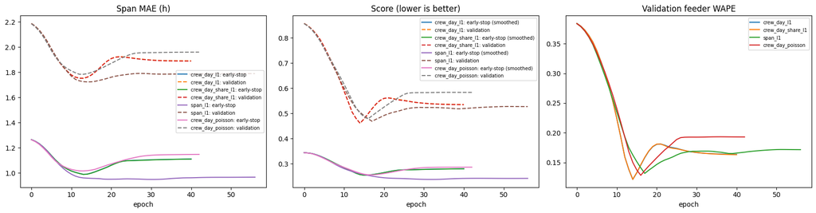

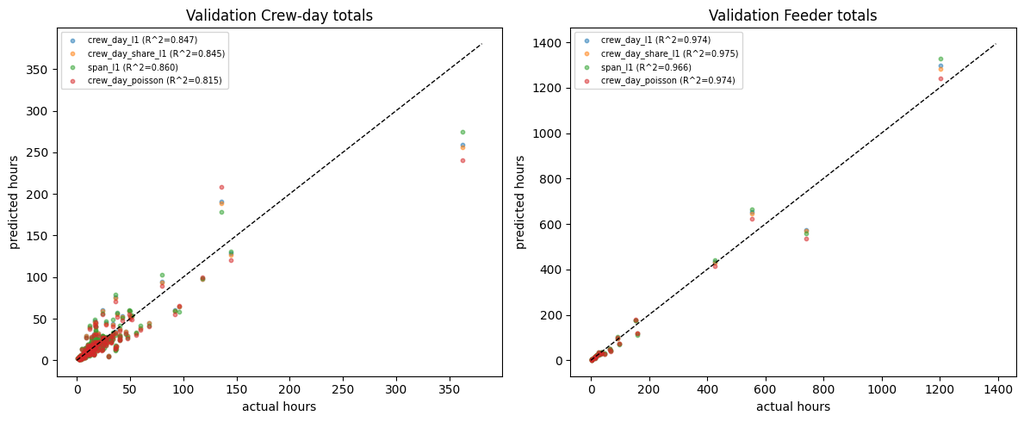

```python
fig, axes = plt.subplots(1, 3, figsize=(17, 4.5))
for name, r in RESULTS.items():
    h = r["histories"][0]   # first seed
    axes[0].plot(h["epoch"], h["early_stop_span_mae"], label=f"{name}: early-stop")
    axes[0].plot(h["epoch"], h["validation_span_mae"], "--", label=f"{name}: validation")
    axes[1].plot(h["epoch"], h["score_smoothed"], label=f"{name}: early-stop (smoothed)")
    axes[1].plot(h["epoch"], h["validation_score"], "--", label=f"{name}: validation")
    axes[2].plot(h["epoch"], h["validation_feeder_wape"], label=name)
for ax, title in zip(axes, ["Span MAE (h)", "Score (lower is better)", "Validation feeder WAPE"]):
    ax.set_title(title); ax.set_xlabel("epoch"); ax.legend(fontsize=7)
fig.tight_layout(); fig.savefig(fig_path("crewday_learning_curves.png"), dpi=120)
if SHOW_PLOTS: plt.show()
else: plt.close(fig)

# add R^2 (coefficient of determination) for each prediction
from sklearn.metrics import r2_score
fig, axes = plt.subplots(1, 2, figsize=(12, 5))
base = pd.DataFrame({"y": val["y"].numpy(), "cd": val["cd"], "feeder": val["feeder"]})
for name in RESULTS:
    base[name] = spread[f"pred_{name}"].to_numpy()
for ax, key, title in [(axes[0], "cd", "Crew-day totals"), (axes[1], "feeder", "Feeder totals")]:
    g = base.groupby(key)[["y", *RESULTS.keys()]].sum()
    for name in RESULTS:
        ax.scatter(g["y"], g[name], s=10, alpha=0.5, label=f"{name} (R^2={r2_score(g['y'], g[name]):.3f})")
    lim = float(g.to_numpy().max()) * 1.05
    ax.plot([0, lim], [0, lim], "k--", lw=1)
    ax.set_xlabel("actual hours"); ax.set_ylabel("predicted hours"); ax.set_title(f"Validation {title}")
    ax.legend(fontsize=7)
fig.tight_layout(); fig.savefig(fig_path("crewday_pred_vs_actual.png"), dpi=120)
if USE_TENSORBOARD:
    first = next(iter(RESULTS))
    w = make_writer(f"{RUN_STAMP}_{first}_s{RESULTS[first]['seeds'][0]}")
    w.add_figure("validation/pred_vs_actual", fig, global_step=RESULTS[first]["best_epochs"][0], close=False)
    w.close()
if SHOW_PLOTS: plt.show()
else: plt.close(fig)
```

```python
UNIT_LEVELS = {"feeder": "feeder"}
if DATA["validation"]["device"] is not None:
    UNIT_LEVELS["device"] = "device"
UNIT_BANDS = {}   # (run, level) -> fitted band and size-bin edges, reused on the holdout


def unit_report(d, pred, level, band=None):
    """Unit totals, WAPE, bias and actual/predicted error band (fitted here unless `band` is given)."""
    u = unit_errors(d["y"].numpy(), pred, d[level])
    u = u[(u["p"] > 0) & (u["y"] > 0)]
    ratio = u["y"] / u["p"]
    if band is None:
        lo, hi = np.quantile(ratio, UNIT_BAND)
        edges = np.quantile(u["n"], [1 / 3, 2 / 3])
        by_size = {}
        for label, mask in (("small", u["n"] <= edges[0]), ("medium", (u["n"] > edges[0]) & (u["n"] <= edges[1])),
                            ("large", u["n"] > edges[1])):
            by_size[label] = (np.quantile(ratio[mask], UNIT_BAND) if mask.sum() >= 5 else (np.nan, np.nan))
        band = {"lo": lo, "hi": hi, "edges": edges, "by_size": by_size}
    inside = (ratio >= band["lo"]) & (ratio <= band["hi"])
    row = {"units": len(u), "median_spans": u["n"].median(),
           "wape": float(np.abs(u["y"] - u["p"]).sum() / u["y"].sum()),
           "total_bias": float(u["p"].sum() / u["y"].sum() - 1),
           "band_lo": band["lo"], "band_hi": band["hi"], "band_width": band["hi"] - band["lo"],
           "coverage": float(inside.mean())}
    for label, (blo, bhi) in band["by_size"].items():
        row[f"width_{label}"] = bhi - blo
    row["size_edges_spans"] = f"<= {band['edges'][0]:.0f} | <= {band['edges'][1]:.0f} | more"
    return row, band


unit_rows = {}
for name in RESULTS:
    pred_val = predict_final(name, DATA["validation"])
    for level in UNIT_LEVELS:
        row, UNIT_BANDS[(name, level)] = unit_report(DATA["validation"], pred_val, level)
        unit_rows[(level, name)] = row
UNIT_TABLE = pd.DataFrame(unit_rows).T
UNIT_TABLE.index.names = ["level", "run"]
vp.show(UNIT_TABLE, "Validation: device vs feeder level", 3)
if "device" not in UNIT_LEVELS:
    print("Device level skipped: set DEVICE_COL to the protective device column.")
```

```
Validation: device vs feeder level
```

| level | run | units | median_spans | wape | total_bias | band_lo | band_hi | band_width | coverage | width_small | width_medium | width_large | size_edges_spans |
| --- | --- | --- | --- | --- | --- | --- | --- | --- | --- | --- | --- | --- | --- |
| feeder | crew_day_l1 | 26 | 12.5 | 0.142313 | -0.016734 | 0.849481 | 1.410267 | 0.560786 | 0.769231 | 0.74097 | 0.492184 | 0.468609 | <= 6 \| <= 17 \| more |
|  | crew_day_share_l1 | 26 | 12.5 | 0.137556 | -0.025328 | 0.851614 | 1.410716 | 0.559102 | 0.769231 | 0.734084 | 0.499545 | 0.475905 | <= 6 \| <= 17 \| more |
|  | span_l1 | 26 | 12.5 | 0.165179 | -0.010677 | 0.813832 | 1.471663 | 0.657831 | 0.769231 | 0.996469 | 0.571978 | 0.527065 | <= 6 \| <= 17 \| more |
|  | crew_day_poisson | 26 | 12.5 | 0.135333 | -0.054388 | 0.840348 | 1.509838 | 0.66949 | 0.769231 | 0.935627 | 0.579311 | 0.464892 | <= 6 \| <= 17 \| more |

```
Device level skipped: set DEVICE_COL to the protective device column.
```

```python
def feeder_validation_results(name):
    """Per-feeder Validation results for one model: span-summed actual vs predicted hours (overall and split
    accessible / inaccessible), the spread of per-feeder span MAE, and span counts per feeder by veg_tier,
    area_class__area_lcxfm (both from ALL_META) and equipment_types (joined in from span_df)."""
    d = DATA["validation"]
    meta = d["meta"]   # the validation rows of ALL_META, row-aligned with d["y"] / d["feeder"] / predictions
    actual = d["y"].numpy()
    pred = predict_final(name, d)

    span = pd.DataFrame({
        "feeder": d["feeder"],
        "actual": actual,
        "pred": pred,
        "abs_err": np.abs(pred - actual),
        "accessible": meta["inaccessible"].to_numpy() == 0,
        "veg_tier": meta["veg_tier"].to_numpy(),
        "area_class__area_lcxfm": meta["area_class__area_lcxfm"].to_numpy(),
        "equipment_types": meta[SPAN_ID_COL].map(span_equip_lookup).to_numpy(),
    })

    g = span.groupby("feeder")
    table = pd.DataFrame({"n_spans": g.size(), "actual_hours": g["actual"].sum(),
                          "predicted_hours": g["pred"].sum(), "span_mae_avg": g["abs_err"].mean(),
                          "span_mae_max": g["abs_err"].max(), "span_mae_min": g["abs_err"].min()})

    acc = (span[span["accessible"]].groupby("feeder")[["actual", "pred"]].sum()
          .rename(columns={"actual": "actual_hours_accessible", "pred": "predicted_hours_accessible"}))
    inacc = (span[~span["accessible"]].groupby("feeder")[["actual", "pred"]].sum()
            .rename(columns={"actual": "actual_hours_inaccessible", "pred": "predicted_hours_inaccessible"}))
    table = table.join(acc, how="left").join(inacc, how="left")
    hour_cols = ["actual_hours_accessible", "predicted_hours_accessible",
                "actual_hours_inaccessible", "predicted_hours_inaccessible"]
    table[hour_cols] = table[hour_cols].fillna(0.0)

    veg_tier_counts = span.groupby(["feeder", "veg_tier"]).size().unstack(fill_value=0).add_prefix("veg_tier__")
    area_counts = (span.groupby(["feeder", "area_class__area_lcxfm"]).size()
                  .unstack(fill_value=0).add_prefix("area_class__area_lcxfm__"))
    access_counts = (span.groupby(["feeder", "accessible"]).size()
                     .unstack(fill_value=0))
    equip_counts = (span.groupby(["feeder", "equipment_types"]).size()
                   .unstack(fill_value=0).add_prefix("equipment_types__"))
    table = table.join(veg_tier_counts, how="left").join(area_counts, how="left").join(equip_counts, how="left").join(access_counts, how="left")
    return table, span


# span -> equipment_types lookup (span_df's crew-day key is SPAN_ID_COL == "bay_unique", same join key used above)
span_equip_lookup = (span_df.assign(**{SPAN_ID_COL: as_id_text(span_df[SPAN_ID_COL])})
                    .drop_duplicates(SPAN_ID_COL, keep="first").set_index(SPAN_ID_COL)["equipment_types"])

FEEDER_VALIDATION, VALIDATION_SPANS, summary_rows = {}, {}, {}
for name in RESULTS:
    table, span = feeder_validation_results(name)
    FEEDER_VALIDATION[name] = table
    VALIDATION_SPANS[name] = span
    acc, inacc = span["accessible"], ~span["accessible"]
    summary_rows[name] = {
        "actual_hours": span["actual"].sum(), "predicted_hours": span["pred"].sum(),
        "actual_hours_accessible": span.loc[acc, "actual"].sum(),
        "predicted_hours_accessible": span.loc[acc, "pred"].sum(),
        "actual_hours_inaccessible": span.loc[inacc, "actual"].sum(),
        "predicted_hours_inaccessible": span.loc[inacc, "pred"].sum(),
        "r2_accessible": r2_score(span.loc[acc, "actual"], span.loc[acc, "pred"]),
        "r2_inaccessible": r2_score(span.loc[inacc, "actual"], span.loc[inacc, "pred"]),
        "r2_overall": r2_score(span["actual"], span["pred"]),
        "avg_span_mae": table["span_mae_avg"].mean(), "max_span_mae": table["span_mae_avg"].max(),
        "min_span_mae": table["span_mae_avg"].min(),
    }
VALIDATION_SUMMARY = pd.DataFrame(summary_rows).T
vp.show(VALIDATION_SUMMARY, "Validation summary per model: R^2 by accessibility + overall, "
       "feeder span-MAE spread (span_mae_avg across feeders)", 3)
first_name = next(iter(RESULTS))
vp.show(FEEDER_VALIDATION[first_name].head(10), f"Feeder-level Validation detail ({first_name})", 3)
```

```
Validation summary per model: R^2 by accessibility + overall, feeder span-MAE spread (span_mae_avg across feeders)
```

|  | actual_hours | predicted_hours | actual_hours_accessible | predicted_hours_accessible | actual_hours_inaccessible | predicted_hours_inaccessible | r2_accessible | r2_inaccessible | r2_overall | avg_span_mae | max_span_mae | min_span_mae |
| --- | --- | --- | --- | --- | --- | --- | --- | --- | --- | --- | --- | --- |
| crew_day_l1 | 3879.0 | 3814.088 | 1838.5 | 1896.226 | 2040.5 | 1917.862 | 0.018 | 0.156 | 0.341 | 1.304 | 4.235 | 0.094 |
| crew_day_share_l1 | 3879.0 | 3780.751 | 1838.5 | 1883.974 | 2040.5 | 1896.777 | 0.031 | 0.154 | 0.342 | 1.302 | 4.289 | 0.102 |
| span_l1 | 3879.0 | 3837.585 | 1838.5 | 1907.556 | 2040.5 | 1930.029 | 0.021 | 0.175 | 0.352 | 1.460 | 4.389 | 0.220 |
| crew_day_poisson | 3879.0 | 3668.030 | 1838.5 | 1882.698 | 2040.5 | 1785.332 | -0.009 | 0.139 | 0.326 | 1.402 | 4.751 | 0.110 |

```
Feeder-level Validation detail (crew_day_l1)
```

| feeder | n_spans | actual_hours | predicted_hours | span_mae_avg | span_mae_max | span_mae_min | actual_hours_accessible | predicted_hours_accessible | actual_hours_inaccessible | predicted_hours_inaccessible | veg_tier__Heavy | veg_tier__Light | veg_tier__Medium | area_class__area_lcxfm__Rural | area_class__area_lcxfm__Suburban | area_class__area_lcxfm__Urban | equipment_types__Lift | equipment_types__Manual | False | True |
| --- | --- | --- | --- | --- | --- | --- | --- | --- | --- | --- | --- | --- | --- | --- | --- | --- | --- | --- | --- | --- |
| 28TH142 | 16 | 28.0 | 32.984001 | 0.472 | 1.099 | 0.000 | 28.0 | 32.984001 | 0.0 | 0.000000 | 0 | 13 | 3 | 0 | 0 | 16 | 16 | 0 | 0 | 16 |
| 28TH243 | 14 | 32.0 | 26.746000 | 0.744 | 2.177 | 0.147 | 31.0 | 25.114000 | 1.0 | 1.632000 | 0 | 9 | 5 | 0 | 0 | 14 | 14 | 0 | 1 | 13 |
| 28TH347 | 17 | 37.0 | 32.502998 | 0.604 | 1.600 | 0.037 | 33.0 | 29.114000 | 4.0 | 3.389000 | 0 | 10 | 7 | 0 | 0 | 17 | 17 | 0 | 2 | 15 |
| 28TH348 | 11 | 18.0 | 20.222000 | 0.356 | 0.825 | 0.021 | 18.0 | 20.222000 | 0.0 | 0.000000 | 0 | 8 | 3 | 0 | 0 | 11 | 11 | 0 | 0 | 11 |
| A647 | 6 | 68.0 | 44.855000 | 4.235 | 8.047 | 1.005 | 0.0 | 0.000000 | 68.0 | 44.855000 | 4 | 0 | 2 | 0 | 6 | 0 | 0 | 6 | 6 | 0 |
| C0917 | 9 | 35.0 | 34.150002 | 1.640 | 4.775 | 0.159 | 35.0 | 34.150002 | 0.0 | 0.000000 | 3 | 0 | 6 | 0 | 9 | 0 | 9 | 0 | 0 | 9 |
| C1317 | 222 | 1201.5 | 1298.197998 | 2.558 | 12.364 | 0.001 | 210.0 | 274.609009 | 991.5 | 1023.588989 | 62 | 13 | 147 | 0 | 214 | 8 | 78 | 144 | 141 | 81 |
| D7811 | 68 | 153.0 | 175.869003 | 0.989 | 4.791 | 0.024 | 142.0 | 168.197006 | 11.0 | 7.672000 | 2 | 37 | 29 | 0 | 9 | 59 | 67 | 1 | 4 | 64 |
| E196 | 180 | 555.0 | 652.883972 | 1.316 | 5.892 | 0.018 | 460.0 | 517.249023 | 95.0 | 135.636002 | 57 | 52 | 69 | 62 | 118 | 0 | 179 | 1 | 29 | 151 |
| E196, E465 | 1 | 2.0 | 2.094000 | 0.094 | 0.094 | 0.094 | 2.0 | 2.094000 | 0.0 | 0.000000 | 0 | 1 | 0 | 0 | 1 | 0 | 1 | 0 | 0 | 1 |

### 6c. Choose the model: accessible and inaccessible hours *(v13 change)*

The pricing question is whether feeder hours come out right for **accessible and inaccessible work separately**, since those are bid differently. Each run is scored on Validation by:

- **feeder WAPE, accessible** and **feeder WAPE, inaccessible**: per feeder, predicted vs actual hours of that kind of span, error as a share of actual hours;
- **total bias** for each kind (e.g. -0.06 = 6% too few hours overall);
- span MAE for each kind, for reference.

`selection_score` = average of the two feeder WAPEs; the lowest wins (`BEST_RUN = "auto"`). `seed_std` is the same score's spread across the run's seeds: if the winner's lead is smaller than about twice that, the top runs are effectively tied and the choice could reasonably go either way.

With `APPLY_ACCESS_SCALE`, each run gets two scale factors (accessible / inaccessible), fitted on the early-stop rows like the single factor in 5c. In v10 every run under-predicted inaccessible spans (-0.4 to -0.8 h per span); separate factors remove that systematic part.

```python
# v13 change: accessibility-aware scaling, validation scoring and model choice
from sklearn.metrics import r2_score


def access_flag(d):
    return pd.to_numeric(d["meta"][ACCESS_COL], errors="coerce").fillna(0).astype(int).to_numpy()


def _ratio(y, p):
    return float(np.sum(y) / max(float(np.sum(p)), 1e-6))


def access_scales_from(raw_es, es):
    """Scale factors fitted on the early-stop rows: overall, and per accessibility group (>= 30 spans each)."""
    y, acc = es["y"].numpy(), access_flag(es)
    overall = _ratio(y, raw_es)
    return {g: (_ratio(y[acc == g], raw_es[acc == g]) if (acc == g).sum() >= 30 else overall) for g in (0, 1)}, overall


def apply_scales(raw, d, scales, overall):
    if not APPLY_ACCESS_SCALE:
        return overall * raw
    return raw * np.where(access_flag(d) == 1, scales[1], scales[0])


def predict_access(name, d):
    """Seed-averaged prediction with the run's accessibility scale factors (used from here on)."""
    r = RESULTS[name]
    return apply_scales(predict_ensemble(name, d), d, r["access_scale"], r["scale"])


def access_report(d, pred):
    """Accuracy for accessible, inaccessible and all spans: span-level and summed per feeder."""
    y, acc, feeder = d["y"].numpy(), access_flag(d), d["feeder"]
    rows = {}
    for label, mask in (("accessible", acc == 0), ("inaccessible", acc == 1), ("all", np.ones(len(y), bool))):
        if mask.sum() < 2:
            continue
        yy, pp = y[mask], pred[mask]
        u = pd.DataFrame({"y": yy, "p": pp, "f": feeder[mask]}).groupby("f")[["y", "p"]].sum()
        rows[label] = {"spans": int(mask.sum()), "feeders": len(u),
                       "actual_hours": yy.sum(), "predicted_hours": pp.sum(),
                       "total_bias": pp.sum() / yy.sum() - 1,
                       "span_mae": np.mean(np.abs(yy - pp)), "span_bias": np.mean(pp - yy), "span_r2": r2_score(yy, pp),
                       "feeder_wape": np.abs(u["y"] - u["p"]).sum() / u["y"].sum(),
                       "feeder_r2": r2_score(u["y"], u["p"]) if len(u) > 2 else np.nan}
    return pd.DataFrame(rows).T


def selection_metrics(report):
    return {"wape_accessible": report.loc["accessible", "feeder_wape"],
            "wape_inaccessible": report.loc["inaccessible", "feeder_wape"],
            "bias_accessible": report.loc["accessible", "total_bias"],
            "bias_inaccessible": report.loc["inaccessible", "total_bias"],
            "span_mae_accessible": report.loc["accessible", "span_mae"],
            "span_mae_inaccessible": report.loc["inaccessible", "span_mae"],
            "wape_all_feeders": report.loc["all", "feeder_wape"],
            "selection_score": 0.5 * (report.loc["accessible", "feeder_wape"]
                                      + report.loc["inaccessible", "feeder_wape"])}


es, val = DATA["early_stop"], DATA["validation"]
SELECTION_ROWS = {}
for name, r in RESULTS.items():
    r["access_scale"], _ = access_scales_from(predict_ensemble(name, es), es)
    row = selection_metrics(access_report(val, predict_access(name, val)))
    seed_scores = []
    for m in r["models"]:   # the same scaling for one seed at a time -> noise level of the selection score
        s_acc, s_all = access_scales_from(predict(m, es), es)
        seed_scores.append(selection_metrics(access_report(val, apply_scales(predict(m, val), val, s_acc, s_all)))
                           ["selection_score"])
    row.update({"scale_accessible": r["access_scale"][0], "scale_inaccessible": r["access_scale"][1],
                "seed_std": np.std(seed_scores, ddof=1) if len(seed_scores) > 1 else np.nan})
    SELECTION_ROWS[name] = row
SELECTION = pd.DataFrame(SELECTION_ROWS).T.sort_values("selection_score")
vp.show(SELECTION, "Validation: model choice on accessible / inaccessible feeder hours (lower is better)", 3)

BEST = SELECTION.index[0] if BEST_RUN == "auto" else BEST_RUN
assert BEST in RESULTS, f"BEST_RUN '{BEST}' is not one of {list(RESULTS)}"
if len(SELECTION) > 1:
    lead = SELECTION["selection_score"].iloc[1] - SELECTION["selection_score"].iloc[0]
    noise = 2 * SELECTION["seed_std"].iloc[:2].max()
    print(f"Chosen run: {BEST} | lead over {SELECTION.index[1]}: {lead:.3f} vs noise level ~{noise:.3f}"
          + ("  -> effectively a tie; the runs are interchangeable on this Validation set" if lead < noise else ""))

VAL_PRED = predict_access(BEST, val)
VAL_ACCESS = access_report(val, VAL_PRED)
vp.show(VAL_ACCESS, f"Validation accuracy by accessibility ({BEST})", 3)
# Feeder error band for the chosen run, with its final (accessibility) scaling; coverage is checked on holdout
_, FEEDER_BAND = unit_report(val, VAL_PRED, "feeder")
print(f"Feeder band (Validation, {BEST}): actual / predicted between {FEEDER_BAND['lo']:.2f} and "
      f"{FEEDER_BAND['hi']:.2f} for 80% of feeders")
```

```
Validation: model choice on accessible / inaccessible feeder hours (lower is better)
```

|  | wape_accessible | wape_inaccessible | bias_accessible | bias_inaccessible | span_mae_accessible | span_mae_inaccessible | wape_all_feeders | selection_score | scale_accessible | scale_inaccessible | seed_std |
| --- | --- | --- | --- | --- | --- | --- | --- | --- | --- | --- | --- |
| crew_day_share_l1 | 0.153 | 0.160 | 0.037 | -0.108 | 1.119 | 3.174 | 0.134 | 0.156 | 0.979 | 0.929 | 0.003 |
| crew_day_l1 | 0.157 | 0.157 | 0.046 | -0.104 | 1.132 | 3.177 | 0.139 | 0.157 | 0.989 | 0.930 | 0.005 |
| span_l1 | 0.162 | 0.176 | 0.048 | -0.086 | 1.094 | 3.123 | 0.162 | 0.169 | 1.077 | 1.030 | 0.006 |
| crew_day_poisson | 0.164 | 0.186 | 0.029 | -0.141 | 1.154 | 3.179 | 0.134 | 0.175 | 0.892 | 0.871 | 0.003 |

```
Chosen run: crew_day_share_l1 | lead over crew_day_l1: 0.001 vs noise level ~0.009  -> effectively a tie; the runs are interchangeable on this Validation set

Validation accuracy by accessibility (crew_day_share_l1)
```

|  | spans | feeders | actual_hours | predicted_hours | total_bias | span_mae | span_bias | span_r2 | feeder_wape | feeder_r2 |
| --- | --- | --- | --- | --- | --- | --- | --- | --- | --- | --- |
| accessible | 629.0 | 24.0 | 1838.5 | 1906.047 | 0.037 | 1.119 | 0.107 | 0.021 | 0.153 | 0.967 |
| inaccessible | 310.0 | 17.0 | 2040.5 | 1821.114 | -0.108 | 3.174 | -0.708 | 0.142 | 0.160 | 0.973 |
| all | 939.0 | 26.0 | 3879.0 | 3727.161 | -0.039 | 1.798 | -0.162 | 0.333 | 0.134 | 0.974 |

```
Feeder band (Validation, crew_day_share_l1): actual / predicted between 0.85 and 1.40 for 80% of feeders
```

### 6c-2. Setup and travel check *(v15 change)*

If setup and travel are spread over spans as a flat average, crew-days with few spans come out **under**-predicted and crew-days with many spans **over**-predicted. The first table bins Validation crew-days by spans worked that day: a bias running from negative to positive across the bins is that pattern; roughly flat bias means the average treatment is adequate. In production the number of spans per crew-day isn't known, so this is a diagnostic of how the crew-day training spreads setup and travel, not a model input. The same check runs on the holdout.

```
Validation: crew-day error by spans worked that day (crew_day_share_l1)
```

| size_bin | crew_days | spans | actual_hours_per_span | predicted_hours_per_span | total_bias | median_day_error |
| --- | --- | --- | --- | --- | --- | --- |
| 1 | 33 | 33 | 5.424 | 3.527 | -0.350 | -0.121 |
| 2-3 | 41 | 101 | 4.733 | 4.114 | -0.131 | 0.010 |
| 4-6 | 63 | 315 | 3.960 | 3.879 | -0.020 | 0.004 |
| 7-10 | 26 | 206 | 3.716 | 4.312 | 0.160 | 0.064 |
| 11+ | 14 | 284 | 4.257 | 3.821 | -0.103 | -0.091 |

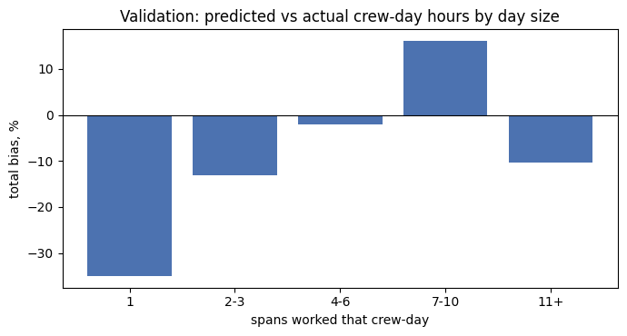

```python
# v15 change: does error depend on crew-day size / surrounding work? (setup and travel spread as an average)
def overhead_check(d, pred, label, show=True):
    y = d["y"].numpy()
    cd = pd.DataFrame({"cd": d["cd"], "y": y, "p": pred}).groupby("cd").agg(actual=("y", "sum"), pred=("p", "sum"),
                                                                            spans=("y", "size"))
    cd["size_bin"] = pd.cut(cd["spans"], [0, 1, 3, 6, 10, 10_000], labels=["1", "2-3", "4-6", "7-10", "11+"])
    g = cd.groupby("size_bin", observed=True)
    by_size = pd.DataFrame({"crew_days": g.size(), "spans": g["spans"].sum(),
                            "actual_hours_per_span": g["actual"].sum() / g["spans"].sum(),
                            "predicted_hours_per_span": g["pred"].sum() / g["spans"].sum(),
                            "total_bias": g["pred"].sum() / g["actual"].sum() - 1,
                            "median_day_error": g.apply(lambda t: (t["pred"] / t["actual"] - 1).median())})
    out = {"by_crewday_size": by_size}
    if show:
        vp.show(by_size, f"{label}: crew-day error by spans worked that day ({BEST})", 3)
        fig, ax = plt.subplots(figsize=(7, 3.8))
        ax.bar(by_size.index.astype(str), 100 * by_size["total_bias"], color="#4C72B0")
        ax.axhline(0, color="black", lw=0.8)
        ax.set_xlabel("spans worked that crew-day"); ax.set_ylabel("total bias, %")
        ax.set_title(f"{label}: predicted vs actual crew-day hours by day size")
        fig.tight_layout(); fig.savefig(fig_path(f"overhead_check_{label.lower()}.png"), dpi=120)
        if SHOW_PLOTS: plt.show()
        else: plt.close(fig)
    return out


VAL_OVERHEAD = overhead_check(DATA["validation"], VAL_PRED, "Validation")
```

```python
span_df.assign(**{SPAN_ID_COL: as_id_text(span_df[SPAN_ID_COL])}) \
       .drop_duplicates(SPAN_ID_COL, keep="first") \
       .set_index(SPAN_ID_COL)[EQUIP_COL]
```

```
bay_unique
15207881      Lift
15132952      Lift
14906728    Manual
14975808    Manual
14907724    Manual
             ...
14939451    Manual
14848417      Lift
14970129    Manual
14878184    Manual
14859793    Manual
Name: equipment_types, Length: 24284, dtype: object
```

```python
span_df.assign(**{SPAN_ID_COL: as_id_text(span_df[SPAN_ID_COL])}) \
       .drop_duplicates(SPAN_ID_COL, keep="first") \
       .set_index(SPAN_ID_COL)["equipment_types"]
```

```
bay_unique
15207881      Lift
15132952      Lift
14906728    Manual
14975808    Manual
14907724    Manual
             ...
14939451    Manual
14848417      Lift
14970129    Manual
14878184    Manual
14859793    Manual
Name: equipment_types, Length: 24284, dtype: object
```

### 6d. Accessibility vs equipment (lift / manual)

Accessible spans should normally be worked with a lift and inaccessible spans manually. This compares the `inaccessible` flag (a model input, derived from road access) with the equipment the crew actually recorded (`EQUIP_COL` in span_data):

```
How equipment_types values are classified (span_data)
```

| equipment_types | spans | class |
| --- | --- | --- |
| Lift | 14616 | Lift |
| Manual | 9520 | Manual |
| Lift,Manual | 102 | Mixed |
| <missing> | 25 | Unknown |
| BYB | 10 | Lift |
| Mower | 7 | Unknown |
| Manual,BYB | 3 | Mixed |
| Lift,SkyTrim | 1 | Lift |

```
bay_unique
15207881      Lift
15132952      Lift
14906728    Manual
14975808    Manual
14907724    Manual
15273984    Manual
15081757      Lift
15226212    Manual
15086390    Manual
14907721    Manual
14967430    Manual
14757756    Manual
15139116      Lift
15030047    Manual
15133566      Lift
15273424    Manual
15128711      Lift
15133580      Lift
15095458    Manual
15099792    Manual
Name: equipment_types, dtype: object
object
['Lift' 'Manual' 'BYB' nan 'Lift,Manual' 'Mower' 'Manual,BYB'
 'Lift,SkyTrim']
Validation: flag agrees with recorded equipment on 88.3% of 939 Lift/Manual spans (Cohen's kappa 0.73); 0 spans have no usable equipment value, 0 are Mixed

Validation: spans by accessibility flag x equipment
```

| equipment access | Lift | Manual | total |
| --- | --- | --- | --- |
| Accessible | 586 | 43 | 629 |
| Inaccessible | 67 | 243 | 310 |
| total | 653 | 286 | 939 |

```
Validation: equipment share within each accessibility group
```

| equipment access | Lift | Manual |
| --- | --- | --- |
| Accessible | 0.932 | 0.068 |
| Inaccessible | 0.216 | 0.784 |

```
Validation: hours by accessibility flag x equipment
```

| access | equipment | spans | actual_hours | predicted_hours | actual_per_span | predicted_per_span | span_mae | total_bias | share_of_actual_hours |
| --- | --- | --- | --- | --- | --- | --- | --- | --- | --- |
| Accessible | Lift | 586 | 1641.0 | 1739.13 | 2.80 | 2.97 | 1.05 | 0.06 | 0.42 |
|  | Manual | 43 | 197.5 | 166.91 | 4.59 | 3.88 | 2.05 | -0.15 | 0.05 |
| Inaccessible | Lift | 67 | 201.0 | 242.33 | 3.00 | 3.62 | 1.35 | 0.21 | 0.05 |
|  | Manual | 243 | 1839.5 | 1578.78 | 7.57 | 6.50 | 3.68 | -0.14 | 0.47 |

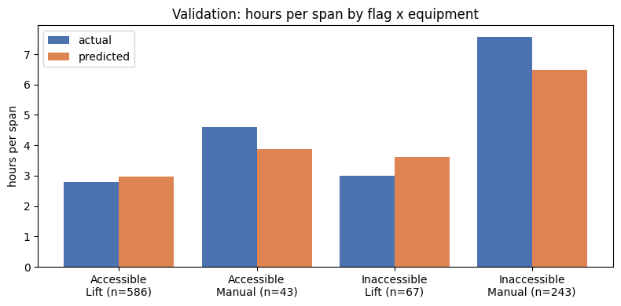

```python
# v13 change: accessibility flag vs recorded equipment
import re
def equipment_class(values):

    text = pd.Series(values, dtype="string").fillna("").str.lower()

    lift_pattern = "|".join(map(re.escape, LIFT_KEYWORDS))
    manual_pattern = "|".join(map(re.escape, MANUAL_KEYWORDS))

    lift = text.str.contains(lift_pattern, regex=True, na=False)
    manual = text.str.contains(manual_pattern, regex=True, na=False)

    out = pd.Series("Unknown", index=text.index)

    out[lift] = "Lift"
    out[manual] = "Manual"
    out[lift & manual] = "Mixed"

    return out


EQUIP_LOOKUP = (span_df.assign(**{SPAN_ID_COL: as_id_text(span_df[SPAN_ID_COL])})
                .drop_duplicates(SPAN_ID_COL, keep="first").set_index(SPAN_ID_COL)[EQUIP_COL])
_raw_counts = EQUIP_LOOKUP.astype("string").fillna("<missing>").value_counts()
vp.show(pd.DataFrame({"spans": _raw_counts, "class": equipment_class(_raw_counts.index).to_numpy()}).head(15),
        f"How {EQUIP_COL} values are classified (span_data)", 0)


print(EQUIP_LOOKUP.head(20))
print(EQUIP_LOOKUP.dtype)
print(EQUIP_LOOKUP.unique()[:20])

def equipment_agreement(d, pred, label, show=True):
    """Flag vs equipment agreement and hours by (accessibility, equipment) for one split."""
    df = pd.DataFrame({
        "access": np.where(access_flag(d) == 1, "Inaccessible", "Accessible"),
        "equipment": equipment_class(d["meta"][SPAN_ID_COL].map(EQUIP_LOOKUP).to_numpy()).to_numpy(),
        "actual": d["y"].numpy(), "pred": pred})
    known = df[df["equipment"].isin(["Lift", "Manual"])]
    expected = np.where(known["access"] == "Accessible", "Lift", "Manual")
    agree = float((known["equipment"].to_numpy() == expected).mean()) if len(known) else np.nan
    p_acc, p_lift = (known["access"] == "Accessible").mean(), (known["equipment"] == "Lift").mean()
    p_chance = p_acc * p_lift + (1 - p_acc) * (1 - p_lift)
    kappa = (agree - p_chance) / (1 - p_chance) if len(known) and p_chance < 1 else np.nan

    counts = pd.crosstab(df["access"], df["equipment"], margins=True, margins_name="total")
    row_share = pd.crosstab(df["access"], df["equipment"], normalize="index")
    g = df.assign(abs_err=(df["pred"] - df["actual"]).abs()).groupby(["access", "equipment"])
    hours = pd.DataFrame({"spans": g.size(), "actual_hours": g["actual"].sum(), "predicted_hours": g["pred"].sum(),
                          "actual_per_span": g["actual"].mean(), "predicted_per_span": g["pred"].mean(),
                          "span_mae": g["abs_err"].mean()})
    hours["total_bias"] = hours["predicted_hours"] / hours["actual_hours"] - 1
    hours["share_of_actual_hours"] = hours["actual_hours"] / df["actual"].sum()
    if show:
        print(f"{label}: flag agrees with recorded equipment on {agree:.1%} of {len(known):,} Lift/Manual spans "
              f"(Cohen's kappa {kappa:.2f}); {int((df['equipment'] == 'Unknown').sum()):,} spans have no usable "
              f"equipment value, {int((df['equipment'] == 'Mixed').sum()):,} are Mixed")
        vp.show(counts, f"{label}: spans by accessibility flag x equipment", 0)
        vp.show(row_share, f"{label}: equipment share within each accessibility group", 3)
        vp.show(hours, f"{label}: hours by accessibility flag x equipment", 2)
        plot = hours.reset_index()
        plot = plot[plot["equipment"].isin(["Lift", "Manual"])]
        if len(plot):
            fig, ax = plt.subplots(figsize=(8, 4))
            xs = np.arange(len(plot))
            ax.bar(xs - 0.2, plot["actual_per_span"], 0.4, label="actual", color="#4C72B0")
            ax.bar(xs + 0.2, plot["predicted_per_span"], 0.4, label="predicted", color="#DD8452")
            ax.set_xticks(xs, [f"{a}\n{e} (n={n})" for a, e, n in zip(plot["access"], plot["equipment"], plot["spans"])])
            ax.set_ylabel("hours per span"); ax.set_title(f"{label}: hours per span by flag x equipment")
            ax.legend()
            fig.tight_layout(); fig.savefig(fig_path(f"access_vs_equipment_{label.lower()}.png"), dpi=120)
            if SHOW_PLOTS: plt.show()
            else: plt.close(fig)
    return {"agreement": agree, "kappa": kappa, "counts": counts, "row_share": row_share, "hours": hours}


VAL_EQUIP = equipment_agreement(val, VAL_PRED, "Validation")
```

```python
# ============================================================
# Build validation analysis dataframe from FULL_X["valid"]
# ============================================================

valid_analysis = FULL_X["valid"].copy()

valid_analysis["access"] = np.where(
    access_flag(val) == 1,
    "Inaccessible",
    "Accessible"
)

valid_analysis["equipment"] = equipment_class(
    val["meta"][SPAN_ID_COL].map(EQUIP_LOOKUP).to_numpy()
).to_numpy()

valid_analysis["raw_equipment"] = (
    val["meta"][SPAN_ID_COL]
    .map(EQUIP_LOOKUP)
    .to_numpy()
)

valid_analysis["actual_hours"] = val["y"].numpy()
valid_analysis["pred_hours"] = VAL_PRED

# ============================================================
# disagreement populations
# ============================================================

inaccessible_lift = valid_analysis[
    (valid_analysis["access"] == "Inaccessible") &
    (valid_analysis["equipment"] == "Lift")
]

accessible_manual = valid_analysis[
    (valid_analysis["access"] == "Accessible") &
    (valid_analysis["equipment"] == "Manual")
]

accessible_lift = valid_analysis[
    (valid_analysis["access"] == "Accessible") &
    (valid_analysis["equipment"] == "Lift")
]

inaccessible_manual = valid_analysis[
    (valid_analysis["access"] == "Inaccessible") &
    (valid_analysis["equipment"] == "Manual")
]

print(f"Inaccessible + Lift     : {len(inaccessible_lift):,}")
print(f"Accessible + Manual     : {len(accessible_manual):,}")
print(f"Accessible + Lift       : {len(accessible_lift):,}")
print(f"Inaccessible + Manual   : {len(inaccessible_manual):,}")
```

```
Inaccessible + Lift     : 67
Accessible + Manual     : 43
Accessible + Lift       : 586
Inaccessible + Manual   : 243
```

```python
# ============================================================
# Compare Accessible Lift vs Inaccessible Lift
# ============================================================

numeric_cols = valid_analysis.select_dtypes(include=np.number).columns

rows = []

for col in numeric_cols:

    a = accessible_lift[col].mean()

    i = inaccessible_lift[col].mean()

    rows.append({
        "feature": col,
        "accessible_lift": a,
        "inaccessible_lift": i,
        "difference": i - a
    })

lift_compare = pd.DataFrame(rows)

display(
    lift_compare.sort_values(
        "difference",
        key=np.abs,
        ascending=False
    ).head(30)
)
```

|  | feature | accessible_lift | inaccessible_lift | difference |
| --- | --- | --- | --- | --- |
| 58 | trim_vol_by_span | 537798.673158 | 497730.654960 | -40068.018198 |
| 55 | railroad_terrain_interaction | 200.654198 | 8152.597015 | 7951.942817 |
| 29 | bay_total_intrusion_volume_(cubic_ft) | 10780.057577 | 13448.642388 | 2668.584811 |
| 23 | bay_os_volume_(cubic_ft) | 9618.808805 | 12176.070299 | 2557.261493 |
| 114 | nearest_alley_ft | 5568.128003 | 6803.338467 | 1235.210464 |
| 61 | nearest_road_aadt | 3422.397611 | 2277.611940 | -1144.785671 |
| 62 | nearest_road_aadt_year | 948.310580 | 663.358209 | -284.952371 |
| 57 | trim_vol_by_length | 3605.245072 | 3329.848173 | -275.396899 |
| 19 | bay_oh_volume_(cubic_ft) | 498.624659 | 640.808060 | 142.183401 |
| 56 | side_intrusion_vol | 1128.665546 | 1243.192836 | 114.527290 |
| 30 | bay_total_span_length_(ft) | 435.958242 | 367.534776 | -68.423466 |
| 32 | bay_ug_volume_(cubic_ft) | 585.968294 | 551.198507 | -34.769786 |
| 43 | intrusion_per_ft | 81.565143 | 106.336550 | 24.771407 |
| 6 | bay_l&r_orange_(ft) | 18.155853 | 32.665224 | 14.509371 |
| 60 | nearest_road_distance_ft | 44.022215 | 56.650762 | 12.628547 |
| 86 | span_length_within_road_100ft | 109.119546 | 96.932164 | -12.187383 |
| 9 | bay_l&r_yellow_(ft) | 37.150256 | 48.114627 | 10.964371 |
| 84 | span_length_within_road_50ft | 91.166316 | 80.346764 | -10.819553 |
| 82 | span_length_within_road_25ft | 45.457824 | 34.685397 | -10.772427 |
| 21 | bay_orange_volume_(cubic_ft) | 19.872304 | 30.512388 | 10.640084 |
| 40 | heavy_contact_vol | 20.324317 | 30.839254 | 10.514936 |
| 36 | heavy_contact_cond | 9.837330 | 17.465609 | 7.628279 |
| 13 | bay_lvl_orange_(ft) | 12.530137 | 20.007463 | 7.477326 |
| 88 | offroad_span_length_50ft | 40.017942 | 47.298833 | 7.280891 |
| 5 | bay_l&r_green_(ft) | 58.050597 | 64.824179 | 6.773582 |
| 64 | nearest_road_urban | 1057.679181 | 1051.000000 | -6.679181 |
| 121 | percent_developed_coverage | 93.029010 | 87.223881 | -5.805130 |
| 127 | heavy_contact_conductor | 107.896570 | 102.304776 | -5.591794 |
| 4 | bay_l&r_blue_(ft) | 77.048328 | 81.839403 | 4.791075 |
| 16 | bay_lvl_yellow_(ft) | 26.180461 | 30.817313 | 4.636853 |

```python
# ============================================================
# Compare Accessible Manual vs Inaccessible Manual
# ============================================================

rows = []

for col in numeric_cols:

    a = accessible_manual[col].mean()

    i = inaccessible_manual[col].mean()

    rows.append({
        "feature": col,
        "accessible_manual": a,
        "inaccessible_manual": i,
        "difference": a - i
    })

manual_compare = pd.DataFrame(rows)

display(
    manual_compare.sort_values(
        "difference",
        key=np.abs,
        ascending=False
    ).head(30)
)
```

|  | feature | accessible_manual | inaccessible_manual | difference |
| --- | --- | --- | --- | --- |
| 58 | trim_vol_by_span | 280065.479744 | 786354.699167 | -506289.219423 |
| 29 | bay_total_intrusion_volume_(cubic_ft) | 6296.629070 | 20231.930905 | -13935.301836 |
| 23 | bay_os_volume_(cubic_ft) | 5479.324651 | 18033.633704 | -12554.309053 |
| 57 | trim_vol_by_length | 2624.005881 | 6459.536487 | -3835.530606 |
| 55 | railroad_terrain_interaction | 463.804651 | 2596.543498 | -2132.738847 |
| 56 | side_intrusion_vol | 766.114884 | 2180.366955 | -1414.252071 |
| 19 | bay_oh_volume_(cubic_ft) | 325.584419 | 1336.677613 | -1011.093195 |
| 61 | nearest_road_aadt | 1935.465116 | 2798.456790 | -862.991674 |
| 62 | nearest_road_aadt_year | 1409.209302 | 665.176955 | 744.032348 |
| 114 | nearest_alley_ft | 2316.767287 | 2825.252704 | -508.485416 |
| 32 | bay_ug_volume_(cubic_ft) | 410.069070 | 776.414115 | -366.345045 |
| 43 | intrusion_per_ft | 71.122802 | 182.055140 | -110.932338 |
| 7 | bay_l&r_purple_ft | 81.361860 | 167.139712 | -85.777851 |
| 4 | bay_l&r_blue_(ft) | 58.021860 | 139.054568 | -81.032707 |
| 5 | bay_l&r_green_(ft) | 41.435814 | 114.571852 | -73.136038 |
| 9 | bay_l&r_yellow_(ft) | 22.066047 | 81.201358 | -59.135312 |
| 11 | bay_lvl_blue_(ft) | 37.844884 | 79.973333 | -42.128450 |
| 14 | bay_lvl_purple_(ft) | 50.931860 | 91.815926 | -40.884065 |
| 12 | bay_lvl_green_(ft) | 28.173256 | 68.415720 | -40.242464 |
| 16 | bay_lvl_yellow_(ft) | 14.910233 | 50.932305 | -36.022072 |
| 88 | offroad_span_length_50ft | 72.869053 | 107.619786 | -34.750733 |
| 40 | heavy_contact_vol | 8.664419 | 42.747860 | -34.083441 |
| 25 | bay_purple_volume_(cubic_ft) | 51.189767 | 17.930247 | 33.259521 |
| 21 | bay_orange_volume_(cubic_ft) | 8.565814 | 41.822058 | -33.256244 |
| 36 | heavy_contact_cond | 5.924104 | 38.746245 | -32.822142 |
| 6 | bay_l&r_orange_(ft) | 9.051628 | 41.214033 | -32.162405 |
| 86 | span_length_within_road_100ft | 45.918242 | 19.640893 | 26.277349 |
| 84 | span_length_within_road_50ft | 30.871817 | 6.231137 | 24.640680 |
| 13 | bay_lvl_orange_(ft) | 6.583488 | 26.450905 | -19.867417 |
| 127 | heavy_contact_conductor | 58.858372 | 77.384321 | -18.525949 |

```python
binary_cols = [
    "road_parallel_10deg",
    "road_parallel_15deg",
    "road_parallel_20deg",
    "road_parallel_30deg",
    "road_follows_span",
    "road_adjacent_majority",
    "parallel_to_alley",
    "alley_within_25ft",
    "alley_within_50ft",
]

binary_cols = [c for c in binary_cols if c in valid_analysis.columns]

(
    valid_analysis
    .groupby(["access", "equipment"])[binary_cols]
    .mean()
    .mul(100)
    .round(1)
    .T
)
```

| access equipment | Accessible Lift | Accessible Manual | Inaccessible Lift | Inaccessible Manual |
| --- | --- | --- | --- | --- |
| road_parallel_10deg | 56.0 | 11.6 | 49.3 | 3.7 |
| road_parallel_15deg | 57.0 | 11.6 | 52.2 | 4.9 |
| road_parallel_20deg | 57.8 | 11.6 | 52.2 | 5.3 |
| road_parallel_30deg | 59.2 | 11.6 | 52.2 | 5.3 |
| road_follows_span | 49.8 | 9.3 | 46.3 | 0.4 |
| road_adjacent_majority | 81.2 | 53.5 | 76.1 | 17.3 |
| parallel_to_alley | 18.9 | 2.3 | 13.4 | 1.6 |
| alley_within_25ft | 23.5 | 4.7 | 17.9 | 3.7 |
| alley_within_50ft | 23.9 | 4.7 | 17.9 | 3.7 |

### 6e. Feature importance: top 20

**Permutation importance** for the chosen run on Validation: one feature at a time is shuffled across spans (its link to the hours is broken, everything else unchanged) and the increase in span MAE is measured, averaged over `PERM_REPEATS` shuffles. A bigger increase means the model relies on that feature more. Feeder WAPE increase is shown alongside in the table.

Read with care: features that carry the same information (several road-distance measures, for example) share their importance, so each can look small although the group matters; values near or below 0 mean the model does not rely on that feature. This replaces the first-layer weight strengths of 5e as the importance measure, because it measures effect on the predictions directly.

```
Permutation importance for crew_day_share_l1: 134 features x 3 shuffles in 16s | baseline Validation span MAE 1.798 h
```

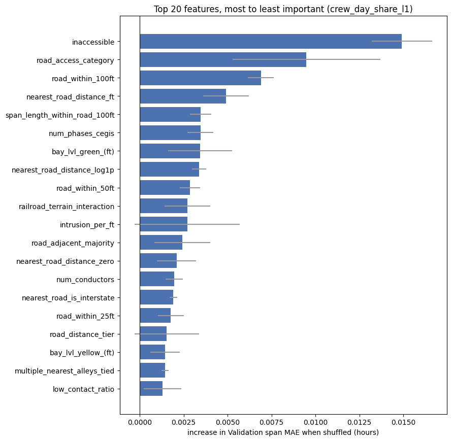

```
Top 20 features (crew_day_share_l1)
```

| feature | span_mae_increase | span_mae_increase_std | feeder_wape_increase | rank |
| --- | --- | --- | --- | --- |
| inaccessible | 0.0149 | 0.0017 | 0.0051 | 1 |
| road_access_category | 0.0095 | 0.0042 | 0.0130 | 2 |
| road_within_100ft | 0.0069 | 0.0007 | 0.0050 | 3 |
| nearest_road_distance_ft | 0.0049 | 0.0013 | 0.0030 | 4 |
| span_length_within_road_100ft | 0.0035 | 0.0006 | 0.0046 | 5 |
| num_phases_cegis | 0.0035 | 0.0007 | 0.0004 | 6 |
| bay_lvl_green_(ft) | 0.0034 | 0.0018 | -0.0030 | 7 |
| nearest_road_distance_log1p | 0.0034 | 0.0004 | 0.0030 | 8 |
| road_within_50ft | 0.0028 | 0.0006 | 0.0038 | 9 |
| railroad_terrain_interaction | 0.0027 | 0.0013 | 0.0002 | 10 |
| intrusion_per_ft | 0.0027 | 0.0030 | -0.0002 | 11 |
| road_adjacent_majority | 0.0024 | 0.0016 | 0.0028 | 12 |
| nearest_road_distance_zero | 0.0021 | 0.0011 | 0.0015 | 13 |
| num_conductors | 0.0020 | 0.0005 | -0.0001 | 14 |
| nearest_road_is_interstate | 0.0019 | 0.0002 | 0.0007 | 15 |
| road_within_25ft | 0.0018 | 0.0007 | 0.0016 | 16 |
| road_distance_tier | 0.0015 | 0.0018 | 0.0047 | 17 |
| bay_lvl_yellow_(ft) | 0.0014 | 0.0008 | 0.0001 | 18 |
| multiple_nearest_alleys_tied | 0.0014 | 0.0002 | -0.0003 | 19 |
| low_contact_ratio | 0.0013 | 0.0011 | -0.0001 | 20 |

```python
# v13 change: permutation importance on Validation for the chosen run
def permutation_importance(name, split="valid", d=None, repeats=PERM_REPEATS, seed=SEED):
    pos = eval_positions(split)
    X = (FULL_X[split] if pos is None else FULL_X[split].iloc[pos])[feature_cols].reset_index(drop=True)
    d = d if d is not None else DATA["validation"]
    y = d["y"].numpy()

    def errors(pred):
        u = pd.DataFrame({"y": y, "p": pred, "f": d["feeder"]}).groupby("f")[["y", "p"]].sum()
        return np.mean(np.abs(y - pred)), np.abs(u["y"] - u["p"]).sum() / u["y"].sum()

    base_mae, base_wape = errors(predict_access(name, d))
    rng = np.random.default_rng(seed)
    rows = []
    for col in feature_cols:
        maes, wapes = [], []
        for _ in range(repeats):
            Xp = X.copy()
            Xp[col] = rng.permutation(Xp[col].to_numpy())
            x_num, x_cat = PREP.transform(Xp)
            mae, wape = errors(predict_access(name, {**d, "x_num": torch.from_numpy(x_num),
                                                     "x_cat": torch.from_numpy(x_cat)}))
            maes.append(mae); wapes.append(wape)
        rows.append({"feature": col, "span_mae_increase": np.mean(maes) - base_mae, "span_mae_increase_std": np.std(maes),
                     "feeder_wape_increase": np.mean(wapes) - base_wape})
    out = pd.DataFrame(rows).set_index("feature").sort_values("span_mae_increase", ascending=False)
    out["rank"] = np.arange(1, len(out) + 1)
    return out, base_mae


t0 = time.time()
FEATURE_IMPORTANCE, _base_mae = permutation_importance(BEST)
print(f"Permutation importance for {BEST}: {len(feature_cols)} features x {PERM_REPEATS} shuffles in "
      f"{time.time() - t0:.0f}s | baseline Validation span MAE {_base_mae:.3f} h")
FEATURE_IMPORTANCE.to_csv(os.path.join(NN_DIR, f"feature_importance_{BEST}_{RUN_STAMP}.csv"))

top = FEATURE_IMPORTANCE.head(TOP_N_FEATURES).iloc[::-1]   # reversed so the most important is drawn at the top
fig, ax = plt.subplots(figsize=(9, 0.38 * len(top) + 1.2))
ax.barh(top.index, top["span_mae_increase"], xerr=top["span_mae_increase_std"], color="#4C72B0", ecolor="#999999")
ax.axvline(0, color="black", lw=0.8)
ax.set_xlabel("increase in Validation span MAE when shuffled (hours)")
ax.set_title(f"Top {len(top)} features, most to least important ({BEST})")
fig.tight_layout(); fig.savefig(fig_path(f"feature_importance_top{TOP_N_FEATURES}.png"), dpi=130)
if SHOW_PLOTS: plt.show()
else: plt.close(fig)
vp.show(FEATURE_IMPORTANCE.head(TOP_N_FEATURES), f"Top {TOP_N_FEATURES} features ({BEST})", 4)
```

## 7 — Save

Saves the crew-day model with everything needed to score new spans: the fitted preparation, the feature list and the settings. Test and holdout stay untouched; score them in the downstream sections once this approach is chosen.

```python
for name, r in RESULTS.items():
    artifact = os.path.join(NN_DIR, f"nn_{name}_{RUN_STAMP}.pt")
    torch.save({"state_dicts": [m.state_dict() for m in r["models"]],   # v12 change: one per seed, averaged
                "seeds": r["seeds"], "target_mode": r["mode"], "spec": r["spec"],
                "feature_cols": feature_cols, "cat_cardinalities": PREP.cardinalities,
                "crew_days_per_batch": CREW_DAYS_PER_BATCH, "crewday_loss_norm": CREWDAY_LOSS_NORM,
                "span_aux_weight": SPAN_AUX_WEIGHT, "share_loss_weight": SHARE_LOSS_WEIGHT,
                "l1_input_penalty": L1_INPUT_PENALTY, "ema_decay": EMA_DECAY, "split_strategy": SPLIT_USED,
                "naive_span": NAIVE_SPAN, "best_epochs": r["best_epochs"],
                "scale_factor": r["scale"]},   # multiply the seed-averaged output by this
               artifact)
    print(f"Saved: {artifact}")
joblib.dump(PREP, os.path.join(NN_DIR, f"nn_prep_{RUN_STAMP}.joblib"))
```

```
Saved: ../deployment/nn/nn_crew_day_l1_20261014-035746.pt
Saved: ../deployment/nn/nn_crew_day_share_l1_20261014-035746.pt
Saved: ../deployment/nn/nn_span_l1_20261014-035746.pt
Saved: ../deployment/nn/nn_crew_day_poisson_20261014-035746.pt
```

```
['../deployment/nn/nn_prep_20261014-035746.joblib']
```

## 8 — Final holdout (one time only)

```
Final holdout, all runs for the record (chosen run: crew_day_share_l1)
```

| run | span_mae | crew_day_mae | feeder_mae | feeder_wape | feeder_ratio | span_ratio | bias_per_span | share_mae | allocation_skill | score |
| --- | --- | --- | --- | --- | --- | --- | --- | --- | --- | --- |
| crew_day_l1 | 2.0087 | 7.8659 | 29.4534 | 0.1843 | 0.4366 | 0.6908 | 0.0210 | 0.0493 | 0.0613 | 0.5637 |
| crew_day_share_l1 | 2.0033 | 7.8423 | 29.5188 | 0.1847 | 0.4376 | 0.6889 | -0.0009 | 0.0493 | 0.0623 | 0.5633 |
| span_l1 | 1.9898 | 7.8910 | 31.1085 | 0.1946 | 0.4612 | 0.6843 | 0.0918 | 0.0491 | 0.0661 | 0.5727 |
| crew_day_poisson | 2.0241 | 7.8897 | 31.6218 | 0.1978 | 0.4688 | 0.6961 | -0.0581 | 0.0495 | 0.0572 | 0.5824 |

```
Holdout accuracy by accessibility (crew_day_share_l1)
```

|  | spans | feeders | actual_hours | predicted_hours | total_bias | span_mae | span_bias | span_r2 | feeder_wape | feeder_r2 |
| --- | --- | --- | --- | --- | --- | --- | --- | --- | --- | --- |
| accessible | 3149.0 | 126.0 | 9881.449 | 9340.663 | -0.055 | 1.491 | -0.172 | 0.169 | 0.222 | 0.944 |
| inaccessible | 2292.0 | 96.0 | 12498.121 | 13033.824 | 0.043 | 2.707 | 0.234 | 0.171 | 0.181 | 0.978 |
| all | 5441.0 | 140.0 | 22379.570 | 22374.487 | -0.000 | 2.003 | -0.001 | 0.252 | 0.185 | 0.971 |

```
Feeder band from Validation (0.85-1.40 x predicted) contains 51% of 138 holdout feeders (target about 80%)
```

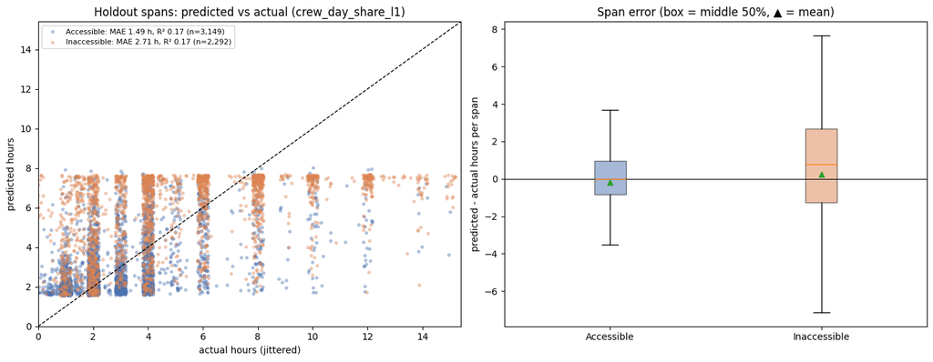

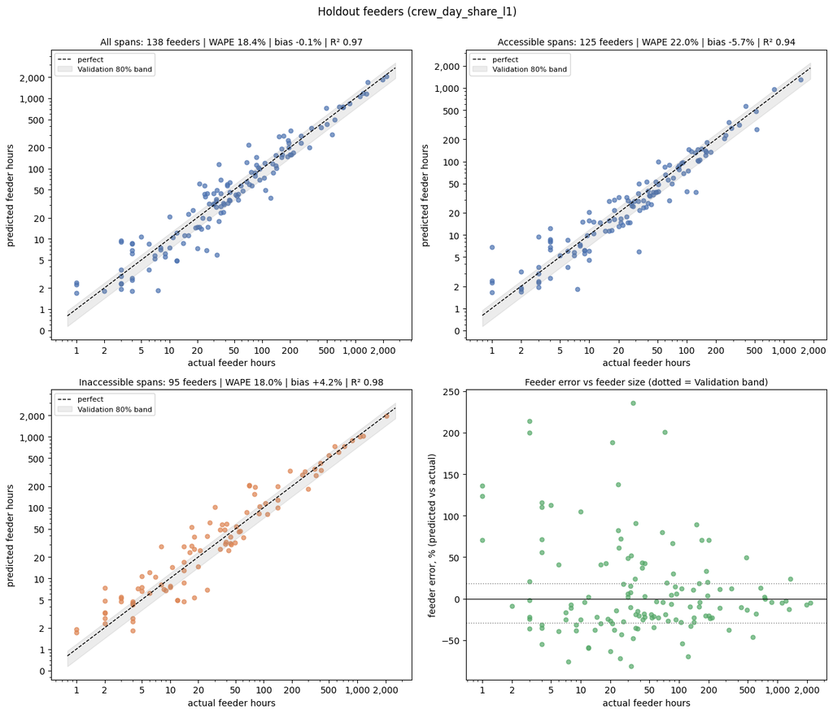

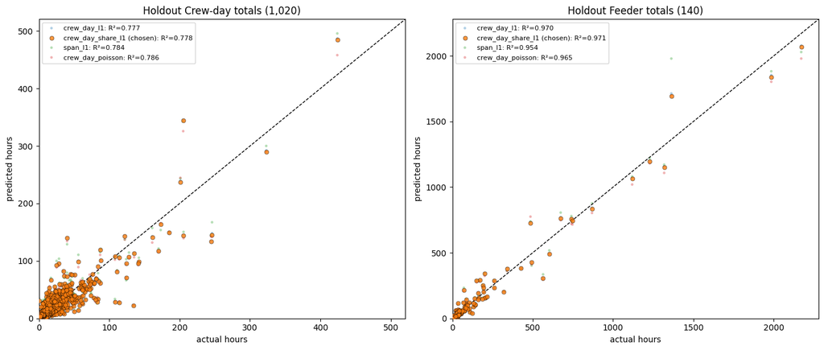

```
Holdout: crew-day error by spans worked that day (crew_day_share_l1)
```

| size_bin | crew_days | spans | actual_hours_per_span | predicted_hours_per_span | total_bias | median_day_error |
| --- | --- | --- | --- | --- | --- | --- |
| 1 | 216 | 216 | 5.138 | 4.675 | -0.090 | 0.010 |
| 2-3 | 284 | 685 | 5.292 | 4.861 | -0.081 | 0.026 |
| 4-6 | 287 | 1419 | 4.698 | 4.436 | -0.056 | 0.003 |
| 7-10 | 137 | 1109 | 3.440 | 3.965 | 0.152 | 0.283 |
| 11+ | 96 | 2012 | 3.560 | 3.650 | 0.025 | 0.016 |

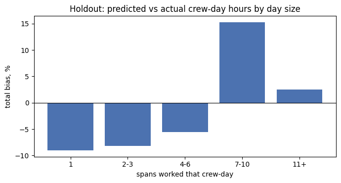

```
Holdout span (5,441) and feeder (140) results saved to ../deployment/nn
```

```python
HOLDOUT_RUN = BEST   # v13 change: the run chosen on Validation in 6c

if READY_FOR_FINAL_HOLDOUT:
    DATA["holdout"] = build_split(FULL_X["holdout"], FULL_Y["holdout"], FULL_META["holdout"],
                                  eval_positions("holdout"))
    hold = DATA["holdout"]
    hold_scores = pd.DataFrame({name: score(hold, predict_access(name, hold)) for name in RESULTS}).T
    hold_scores.index.name = "run"
    vp.show(hold_scores, f"Final holdout, all runs for the record (chosen run: {HOLDOUT_RUN})", 4)

    HOLD_PRED = predict_access(HOLDOUT_RUN, hold)
    HOLD_ACCESS = access_report(hold, HOLD_PRED)
    vp.show(HOLD_ACCESS, f"Holdout accuracy by accessibility ({HOLDOUT_RUN})", 3)
    hold_band_row, _ = unit_report(hold, HOLD_PRED, "feeder", band=FEEDER_BAND)
    print(f"Feeder band from Validation ({FEEDER_BAND['lo']:.2f}-{FEEDER_BAND['hi']:.2f} x predicted) contains "
          f"{hold_band_row['coverage']:.0%} of {hold_band_row['units']} holdout feeders (target about 80%)")

    hs = pd.DataFrame({"feeder": hold["feeder"], "actual": hold["y"].numpy(), "pred": HOLD_PRED,
                       "access": np.where(access_flag(hold) == 1, "Inaccessible", "Accessible")})
    colors = {"Accessible": "#4C72B0", "Inaccessible": "#DD8452"}

    # Span level: predicted vs actual, and error distribution
    fig, axes = plt.subplots(1, 2, figsize=(14, 5.5))
    jitter = np.random.default_rng(SEED).uniform(-0.2, 0.2, len(hs))   # hours are mostly whole numbers
    lim = float(np.quantile(np.r_[hs["actual"], hs["pred"]], 0.99)) * 1.1
    for access, sub in hs.groupby("access"):
        mae, r2 = np.mean(np.abs(sub["actual"] - sub["pred"])), r2_score(sub["actual"], sub["pred"])
        axes[0].scatter(sub["actual"] + jitter[sub.index], sub["pred"], s=8, alpha=0.35, color=colors[access],
                        label=f"{access}: MAE {mae:.2f} h, R² {r2:.2f} (n={len(sub):,})")
    axes[0].plot([0, lim], [0, lim], "k--", lw=1)
    axes[0].set_xlim(0, lim); axes[0].set_ylim(0, lim)
    axes[0].set_xlabel("actual hours (jittered)"); axes[0].set_ylabel("predicted hours")
    axes[0].set_title(f"Holdout spans: predicted vs actual ({HOLDOUT_RUN})"); axes[0].legend(fontsize=8)
    groups = [(a, (sub["pred"] - sub["actual"]).to_numpy()) for a, sub in hs.groupby("access")]
    bp = axes[1].boxplot([e for _, e in groups], showfliers=False, patch_artist=True, showmeans=True)
    axes[1].set_xticks(range(1, len(groups) + 1), [a for a, _ in groups])
    for patch, (access, _) in zip(bp["boxes"], groups):
        patch.set_facecolor(colors[access]); patch.set_alpha(0.5)
    axes[1].axhline(0, color="black", lw=0.8)
    axes[1].set_ylabel("predicted - actual hours per span"); axes[1].set_title("Span error (box = middle 50%, ▲ = mean)")
    fig.tight_layout(); fig.savefig(fig_path("holdout_span_accuracy.png"), dpi=130)
    if SHOW_PLOTS: plt.show()
    else: plt.close(fig)

    from matplotlib.ticker import FuncFormatter, LogLocator, NullFormatter

    def plain_log_axes(ax, x=True, y=True):
        """Log scale with plain numbers (50, 100, 200) instead of 10^2 notation."""
        for on, axis, setter in ((x, ax.xaxis, ax.set_xscale), (y, ax.yaxis, ax.set_yscale)):
            if on:
                setter("log")
                axis.set_major_locator(LogLocator(subs=(1, 2, 5)))
                axis.set_major_formatter(FuncFormatter(lambda v, _: f"{v:,.0f}"))
                axis.set_minor_formatter(NullFormatter())

    # Feeder level: totals (all / accessible / inaccessible) and error vs feeder size
    fig, axes = plt.subplots(2, 2, figsize=(13, 11))
    panels = [("All spans", hs), ("Accessible spans", hs[hs["access"] == "Accessible"]),
              ("Inaccessible spans", hs[hs["access"] == "Inaccessible"])]
    for ax, (title, sub) in zip(axes.flat[:3], panels):
        u = sub.groupby("feeder")[["actual", "pred"]].sum()
        u = u[(u["actual"] > 0) & (u["pred"] > 0)]
        if len(u) < 2:
            ax.set_title(f"{title}: too few feeders"); continue
        wape = np.abs(u["actual"] - u["pred"]).sum() / u["actual"].sum()
        bias = u["pred"].sum() / u["actual"].sum() - 1
        ax.scatter(u["actual"], u["pred"], s=22, alpha=0.7, color="#4C72B0" if title != "Inaccessible spans" else "#DD8452")
        lo_v, hi_v = float(u.min().min()) * 0.8, float(u.max().max()) * 1.25
        grid = np.geomspace(lo_v, hi_v, 50)
        ax.plot(grid, grid, "k--", lw=1, label="perfect")
        ax.fill_between(grid, grid / FEEDER_BAND["hi"], grid / FEEDER_BAND["lo"], color="grey", alpha=0.15,
                        label="Validation 80% band")
        plain_log_axes(ax)
        ax.set_xlabel("actual feeder hours"); ax.set_ylabel("predicted feeder hours")
        ax.set_title(f"{title}: {len(u)} feeders | WAPE {wape:.1%} | bias {bias:+.1%} | "
                     f"R² {r2_score(u['actual'], u['pred']):.2f}", fontsize=10)
        ax.legend(fontsize=8)
    u = hs.groupby("feeder").agg(actual=("actual", "sum"), pred=("pred", "sum"), spans=("actual", "size"))
    u = u[u["actual"] > 0]
    ax = axes.flat[3]
    ax.scatter(u["actual"], 100 * (u["pred"] / u["actual"] - 1), s=22, alpha=0.7, color="#55A868")
    ax.axhline(0, color="black", lw=0.8)
    ax.axhline(100 * (1 / FEEDER_BAND["hi"] - 1), color="grey", ls=":", lw=1)
    ax.axhline(100 * (1 / FEEDER_BAND["lo"] - 1), color="grey", ls=":", lw=1)
    plain_log_axes(ax, y=False)
    ax.set_xlabel("actual feeder hours"); ax.set_ylabel("feeder error, % (predicted vs actual)")
    ax.set_title("Feeder error vs feeder size (dotted = Validation band)", fontsize=10)
    fig.suptitle(f"Holdout feeders ({HOLDOUT_RUN})", y=1.0)
    fig.tight_layout(); fig.savefig(fig_path("holdout_feeder_accuracy.png"), dpi=130)
    if SHOW_PLOTS: plt.show()
    else: plt.close(fig)

    # v15 change: crew-day and feeder totals on linear axes, every run, R² in the legend (same view as Validation)
    fig, axes = plt.subplots(1, 2, figsize=(14, 6))
    base = pd.DataFrame({"y": hold["y"].numpy(), "cd": hold["cd"], "feeder": hold["feeder"]})
    for name in RESULTS:
        base[name] = HOLD_PRED if name == HOLDOUT_RUN else predict_access(name, hold)
    for ax, key, title in [(axes[0], "cd", "Crew-day totals"), (axes[1], "feeder", "Feeder totals")]:
        g = base.groupby(key)[["y", *RESULTS.keys()]].sum()
        for name in RESULTS:
            chosen = name == HOLDOUT_RUN
            ax.scatter(g["y"], g[name], s=26 if chosen else 10, alpha=0.8 if chosen else 0.35, zorder=3 if chosen else 2,
                       edgecolor="black" if chosen else "none", linewidth=0.4,
                       label=f"{name}{' (chosen)' if chosen else ''}: R²={r2_score(g['y'], g[name]):.3f}")
        lim = float(g.to_numpy().max()) * 1.05
        ax.plot([0, lim], [0, lim], "k--", lw=1)
        ax.set_xlim(0, lim); ax.set_ylim(0, lim)
        ax.set_xlabel("actual hours"); ax.set_ylabel("predicted hours")
        ax.set_title(f"Holdout {title} ({len(g):,})"); ax.legend(fontsize=8)
    fig.tight_layout(); fig.savefig(fig_path("holdout_crewday_feeder_r2.png"), dpi=130)
    if SHOW_PLOTS: plt.show()
    else: plt.close(fig)

    HOLD_OVERHEAD = overhead_check(hold, HOLD_PRED, "Holdout")   # v15 change

   # HOLD_EQUIP = equipment_agreement(hold, HOLD_PRED, "Holdout")

    # Result files
    span_out = hold["meta"][[SPAN_ID_COL, FEEDER_COL, CREW_DAY_COL, ACCESS_COL]].copy()
    #span_out["equipment"] = equipment_class(span_out[SPAN_ID_COL].map(EQUIP_LOOKUP).to_numpy()).to_numpy()
    span_out["actual_hours"] = hold["y"].numpy()
    span_out["predicted_hours"] = HOLD_PRED
    for name in RESULTS:
        span_out[f"pred_{name}"] = predict_access(name, hold)
    span_out.to_csv(os.path.join(NN_DIR, f"holdout_span_predictions_{RUN_STAMP}.csv"), index=False)
    g = span_out.assign(acc_a=np.where(span_out[ACCESS_COL] == 0, span_out["actual_hours"], 0.0),
                        acc_p=np.where(span_out[ACCESS_COL] == 0, span_out["predicted_hours"], 0.0),
                        ina_a=np.where(span_out[ACCESS_COL] == 1, span_out["actual_hours"], 0.0),
                        ina_p=np.where(span_out[ACCESS_COL] == 1, span_out["predicted_hours"], 0.0)).groupby(FEEDER_COL)
    HOLD_FEEDERS = pd.DataFrame({"spans": g.size(), "actual_hours": g["actual_hours"].sum(),
                                 "predicted_hours": g["predicted_hours"].sum(),
                                 "actual_accessible": g["acc_a"].sum(), "predicted_accessible": g["acc_p"].sum(),
                                 "actual_inaccessible": g["ina_a"].sum(), "predicted_inaccessible": g["ina_p"].sum()})
    HOLD_FEEDERS["error_pct"] = HOLD_FEEDERS["predicted_hours"] / HOLD_FEEDERS["actual_hours"] - 1
    HOLD_FEEDERS.to_csv(os.path.join(NN_DIR, f"holdout_feeder_results_{RUN_STAMP}.csv"))
    print(f"Holdout span ({len(span_out):,}) and feeder ({len(HOLD_FEEDERS)}) results saved to {NN_DIR}")
else:
    print("Holdout gate is closed (READY_FOR_FINAL_HOLDOUT = False). Nothing was scored.")
```

## 9 — Historical lift vs manual hours

Actual recorded hours for every labeled span (all splits, including spans set aside for the time-based holdout), by accessibility flag and recorded equipment. This is the history the veg team can set against T&E $/hr rates. It uses holdout hours, so it runs only after the holdout gate is open. Saved as `historical_hours_by_access_equipment.csv` in `NN_DIR`.

```python
if READY_FOR_FINAL_HOLDOUT:
    hist = pd.DataFrame({
        "access": np.where(pd.to_numeric(ALL_META[ACCESS_COL], errors="coerce").fillna(0).astype(int) == 1,
                           "Inaccessible", "Accessible"),
        "equipment": equipment_class(ALL_META[SPAN_ID_COL].map(EQUIP_LOOKUP).to_numpy()).to_numpy(),
        "hours": ALL_Y.to_numpy(), "feeder": ALL_META[FEEDER_COL].to_numpy()})
    g = hist.groupby(["access", "equipment"])
    HISTORICAL = pd.DataFrame({"spans": g.size(), "feeders": g["feeder"].nunique(), "total_hours": g["hours"].sum(),
                               "hours_per_span": g["hours"].mean(), "median_hours_per_span": g["hours"].median()})
    HISTORICAL["share_of_all_hours"] = HISTORICAL["total_hours"] / hist["hours"].sum()
    vp.show(HISTORICAL, "All labeled spans: actual hours by accessibility flag x recorded equipment", 3)
    by_equip = hist.groupby("equipment")["hours"].agg(["size", "sum", "mean"]).rename(
        columns={"size": "spans", "sum": "total_hours", "mean": "hours_per_span"})
    vp.show(by_equip, "All labeled spans: actual hours by recorded equipment", 3)
    HISTORICAL.to_csv(os.path.join(NN_DIR, "historical_hours_by_access_equipment.csv"))
else:
    print("Runs after the holdout gate is opened (uses holdout hours).")
```

```
All labeled spans: actual hours by accessibility flag x recorded equipment
```

| access | equipment | spans | feeders | total_hours | hours_per_span | median_hours_per_span | share_of_all_hours |
| --- | --- | --- | --- | --- | --- | --- | --- |
| Accessible | Lift | 11793 | 375 | 36118.90 | 3.063 | 2.0 | 0.365 |
|  | Manual | 1133 | 198 | 5204.54 | 4.594 | 4.0 | 0.053 |
|  | Mixed | 14 | 13 | 64.05 | 4.575 | 4.0 | 0.001 |
|  | Unknown | 18 | 7 | 18.00 | 1.000 | 0.0 | 0.000 |
| Inaccessible | Lift | 2170 | 254 | 7405.95 | 3.413 | 3.0 | 0.075 |
|  | Manual | 8123 | 222 | 49419.09 | 6.084 | 5.0 | 0.499 |
|  | Mixed | 89 | 25 | 698.65 | 7.850 | 6.0 | 0.007 |
|  | Unknown | 9 | 7 | 29.00 | 3.222 | 2.0 | 0.000 |

```
All labeled spans: actual hours by recorded equipment
```

| equipment | spans | total_hours | hours_per_span |
| --- | --- | --- | --- |
| Lift | 13963 | 43524.85 | 3.117 |
| Manual | 9256 | 54623.63 | 5.901 |
| Mixed | 103 | 762.70 | 7.405 |
| Unknown | 27 | 47.00 | 1.741 |

```python
# investigate Accessible, Manual and Inaccessible, Lift
```

## 10 — Final model for production

The holdout-scored model was trained on only the `fit` rows (a few thousand spans), because the evaluation design set aside every older span connected to the holdout. For production it is better to use all of it:

- `FINAL_TRAINING_DATA = "all_labeled"` (default): retrain the chosen run (same settings, same seeds) on every labeled span with a known crew-day, from all splits. `FINAL_ES_SHARE` of the spans, as whole linked feeder groups, is held back for early stopping and for the accessible / inaccessible scale factors. The data preparation is refitted on the new training rows. There is no untouched data left to score this model on, so its accuracy is the holdout result above: it should be at least as good, since it learns from more data with the same recipe.
- `"as_evaluated"`: save exactly the model that was scored on the holdout.

Saved to `PRODUCTION_DIR`: `production_bundle_<stamp>.pt` (network weights for every seed, data preparation, feature list with training ranges, scale factors, feeder band, list of feeders used in modeling) and a readable `production_manifest_<stamp>.json`. The scoring notebook `nn_veg_production_scoring.ipynb` loads the bundle.

def prep_state(p): """Plain-Python copy of a fitted TabularPrep, so the scoring notebook needs no pickled class.""" return {"num_cols": list(p.num_cols), "cat_cols": list(p.cat_cols), "na_cols": list(p.na_cols), "log_cols": list(p.log_cols), "clip_z": float(p.clip_z), "medians": {k: float(v) for k, v in p.medians.items()}, "mean": {k: float(v) for k, v in p.mean.items()}, "std": {k: float(v) for k, v in p.std.items()}, "vocab": {c: {str(k): int(v) for k, v in p.vocab[c].items()} for c in p.cat_cols}}

def feature_profile(X, p): """Training-data profile per feature, used by the scoring notebook's checks.""" prof = {} num = p._as_float(X[p.num_cols]) for c in p.num_cols: s = num[c] prof[c] = {"kind": "numeric", "missing_rate": float(s.isna().mean()), "p01": float(s.quantile(0.01)) if s.notna().any() else None, "p99": float(s.quantile(0.99)) if s.notna().any() else None, "min": float(s.min()) if s.notna().any() else None, "max": float(s.max()) if s.notna().any() else None} for c in p.cat_cols: prof[c] = {"kind": "categorical", "missing_rate": float(X[c].isna().mean()), "categories": sorted(map(str, p.vocab[c].keys()))} return prof

if not READY_FOR_FINAL_HOLDOUT: print("Run the holdout (Step 8) first: set READY_FOR_FINAL_HOLDOUT = True once the run is chosen on Validation.") else: run = RESULTS[BEST] if FINAL_TRAINING_DATA == "all_labeled": labeled = (ALL_META["work_date"].notna() & ALL_META["crew_day_known"]).to_numpy() pool_meta = ALL_META.loc[labeled].reset_index(drop=True) pool_X, pool_Y = ALL_X.loc[labeled].reset_index(drop=True), ALL_Y.loc[labeled].reset_index(drop=True) groups = feeder_crewday_components(pool_meta) sizes = groups.value_counts() if sizes.iloc[0] / len(pool_meta) > 2 * FINAL_ES_SHARE: # one linked group too big to hold back: use feeders groups = "feeder|" + pool_meta[FEEDER_COL].astype(str) sizes = groups.value_counts() print("Largest linked feeder group is too big for early stopping; using whole feeders instead.") order = np.random.default_rng(SEED).permutation(sizes.index.to_numpy()) sz = sizes.loc[order].to_numpy() es_groups = set(order[((np.cumsum(sz) - sz / 2) / sz.sum()) <= FINAL_ES_SHARE]) or {order[0]} is_es = groups.isin(es_groups).to_numpy() final_fit_pos, final_es_pos = np.flatnonzero(~is_es), np.flatnonzero(is_es) print(f"Final refit on all labeled spans: fit {len(final_fit_pos):,} | early stop {len(final_es_pos):,} " f"({len(es_groups)} groups) | {pool_meta[FEEDER_COL].nunique()} feeders")

```
    _saved = (PREP, DATA, NAIVE_SPAN)   # train_model reads these globals; restored afterwards
    try:
        PREP = TabularPrep(NN_CFG["min_category_count"], NN_CFG["skew_log_threshold"], NN_CFG["clip_z"])
        PREP.fit(pool_X.iloc[final_fit_pos][feature_cols])
        DATA = {"fit": build_split(pool_X, pool_Y, pool_meta, final_fit_pos),
                "early_stop": build_split(pool_X, pool_Y, pool_meta, final_es_pos)}
        DATA["validation"] = DATA["early_stop"]   # monitoring only; no separate data remains
        NAIVE_SPAN = float(DATA["fit"]["y"].mean())
        fits = [train_model(run["mode"], run["spec"], run_name=f"{RUN_STAMP}_FINAL_{BEST}_s{sd}", seed=sd)
                for sd in run["seeds"]]
        final_models = [f["model"] for f in fits]
        final_prep, final_naive = PREP, NAIVE_SPAN
        raw_es = np.mean([predict(m, DATA["early_stop"]) for m in final_models], axis=0)
        final_access_scale, final_scale = access_scales_from(raw_es, DATA["early_stop"])
        vp.show(access_report(DATA["early_stop"], apply_scales(raw_es, DATA["early_stop"],
                                                               final_access_scale, final_scale)),
                "Final model on its early-stop groups (used for stopping and scaling - not an independent test)", 3)
        final_profile = feature_profile(pool_X.iloc[final_fit_pos][feature_cols], PREP)
        n_train = len(final_fit_pos)
    finally:
        PREP, DATA, NAIVE_SPAN = _saved
else:
    final_models, final_prep, final_naive = run["models"], PREP, NAIVE_SPAN
    final_access_scale, final_scale = run["access_scale"], run["scale"]
    final_profile = feature_profile(FULL_X["train"].iloc[fit_pos][feature_cols], PREP)
    n_train = len(fit_pos)

m0 = final_models[0]
bundle = {
    "format": "veg_nn_production_v1", "created": time.strftime("%Y-%m-%d %H:%M:%S"), "run_stamp": RUN_STAMP,
    "run": BEST, "target_mode": run["mode"], "loss": run["spec"]["loss"], "seeds": run["seeds"],
    "training_data": FINAL_TRAINING_DATA, "n_training_spans": int(n_train),
    "arch": {"n_num": int(m0.first_layer.in_features - sum(e.embedding_dim for e in m0.embs)),
             "cat_cards": [int(e.num_embeddings) for e in m0.embs], "width": run["spec"]["width"],
             "n_blocks": run["spec"]["n_blocks"], "dropout": run["spec"]["dropout"],
             "emb_dropout": run["spec"]["emb_dropout"]},
    "state_dicts": [{k: v.detach().cpu() for k, v in m.state_dict().items()} for m in final_models],
    "prep_state": prep_state(final_prep), "feature_cols": list(feature_cols), "feature_profile": final_profile,
    "access_col": ACCESS_COL, "apply_access_scale": APPLY_ACCESS_SCALE, "scale_overall": float(final_scale),
    "scale_by_access": {"accessible": float(final_access_scale[0]), "inaccessible": float(final_access_scale[1])},
    "naive_span": float(final_naive),
    "feeder_band": {"lo": float(FEEDER_BAND["lo"]), "hi": float(FEEDER_BAND["hi"]),
                    "percentiles": list(UNIT_BAND), "fitted_on": "Validation (chosen run, as evaluated)",
                    "holdout_coverage": float(hold_band_row["coverage"])},
    "modeling_feeders": sorted(set(ALL_META[FEEDER_COL].astype(str))),
    "historical_feeders": sorted(set(span_df[FEEDER_COL].astype(str))) if FEEDER_COL in span_df.columns else [],
    "validation_selection": SELECTION.reset_index().to_dict(orient="records"),
    "holdout_by_access": HOLD_ACCESS.reset_index().to_dict(orient="records"),
    "feature_importance_top": FEATURE_IMPORTANCE.head(TOP_N_FEATURES).reset_index().to_dict(orient="records"),
}
BUNDLE_PATH = os.path.join(PRODUCTION_DIR, f"production_bundle_{RUN_STAMP}.pt")
torch.save(bundle, BUNDLE_PATH)
manifest = {k: bundle[k] for k in ("format", "created", "run_stamp", "run", "target_mode", "loss", "seeds",
                                   "training_data", "n_training_spans", "arch", "feature_cols", "access_col",
                                   "apply_access_scale", "scale_overall", "scale_by_access", "feeder_band")}
manifest["n_modeling_feeders"] = len(bundle["modeling_feeders"])
manifest["feature_kinds"] = {c: v["kind"] for c, v in final_profile.items()}
with open(os.path.join(PRODUCTION_DIR, f"production_manifest_{RUN_STAMP}.json"), "w") as fh:
    json.dump(manifest, fh, indent=2, default=str)
print(f"Saved production model: {BUNDLE_PATH}")
print(f"  run {BEST} | {len(final_models)} seeds | trained on {n_train:,} spans | scale accessible "
      f"{final_access_scale[0]:.3f}, inaccessible {final_access_scale[1]:.3f}")
```